# Прогнозирование оттока

## Неделя 5

Глазунов А.В.

Загрузим библиотеки

```python
from sklearn.base import BaseEstimator, TransformerMixin


import warnings
warnings.filterwarnings('ignore')
import seaborn as sns
from matplotlib import pyplot as plt
sns.set_style("darkgrid")
import pandas as pd
import numpy as np
from scipy import stats
import itertools
import random
from category_encoders import LeaveOneOutEncoder,TargetEncoder, BinaryEncoder,SumEncoder,BackwardDifferenceEncoder
from sklearn import model_selection, metrics, pipeline, preprocessing,impute
from sklearn.model_selection import train_test_split,StratifiedKFold, cross_val_score,GridSearchCV
from sklearn.feature_selection import SelectFromModel
from sklearn.svm import LinearSVC
from sklearn.linear_model import LogisticRegression
import xgboost as xgb
from sklearn.linear_model import SGDClassifier
from sklearn.naive_bayes import MultinomialNB
from sklearn.neighbors import KNeighborsClassifier
from sklearn.ensemble import RandomForestClassifier
from sklearn.metrics import accuracy_score,roc_auc_score,f1_score,classification_report,roc_curve, confusion_matrix,average_precision_score,precision_recall_curve,auc,precision_score,recall_score
```

### 1. Бейзлайн с прошлой недели

Загрузим данные

```python
features = pd.read_csv('orange_small_churn_data.train')
labels = pd.read_csv('orange_small_churn_labels.train',header= None,names=['target'])
feats_train,feats_val,labels_train,labels_val = train_test_split(features,labels, test_size = 0.3,\
                                                                   shuffle=True,random_state=42,\
                                                                   stratify = labels)
feats_train.head()
```

|  | Var1 | Var2 | Var3 | Var4 | Var5 | Var6 | Var7 | Var8 | Var9 | Var10 | ... | Var221 | Var222 | Var223 | Var224 | Var225 | Var226 | Var227 | Var228 | Var229 | Var230 |
| --- | --- | --- | --- | --- | --- | --- | --- | --- | --- | --- | --- | --- | --- | --- | --- | --- | --- | --- | --- | --- | --- |
| 6892 | NaN | NaN | NaN | 0.0 | NaN | NaN | NaN | NaN | NaN | NaN | ... | oslk | 76DJixu | LM8l689qOp | NaN | NaN | Qu4f | RAYp | F2FyR07IdsN7I | NaN | NaN |
| 34821 | NaN | NaN | NaN | NaN | 0.0 | NaN | NaN | NaN | NaN | 0.0 | ... | oslk | G9maF5M | NaN | NaN | NaN | w_Ub | RAYp | F2FyR07IdsN7I | NaN | NaN |
| 34190 | NaN | NaN | NaN | NaN | NaN | 98.0 | 0.0 | NaN | NaN | NaN | ... | oslk | DQ3u3MC | LM8l689qOp | NaN | NaN | Qu4f | RAYp | F2FyR07IdsN7I | NaN | NaN |
| 24541 | NaN | NaN | NaN | NaN | NaN | 938.0 | 7.0 | NaN | NaN | NaN | ... | zCkv | catzS2D | jySVZNlOJy | NaN | ELof | WqMG | ZI9m | TCU50_Yjmm6GIBZ0lL_ | mj86 | NaN |
| 31483 | NaN | NaN | NaN | NaN | NaN | 602.0 | 7.0 | NaN | NaN | NaN | ... | oslk | nRgz4Af | LM8l689qOp | NaN | NaN | FSa2 | RAYp | F2FyR07IdsN7I | NaN | NaN |

5 rows × 230 columns

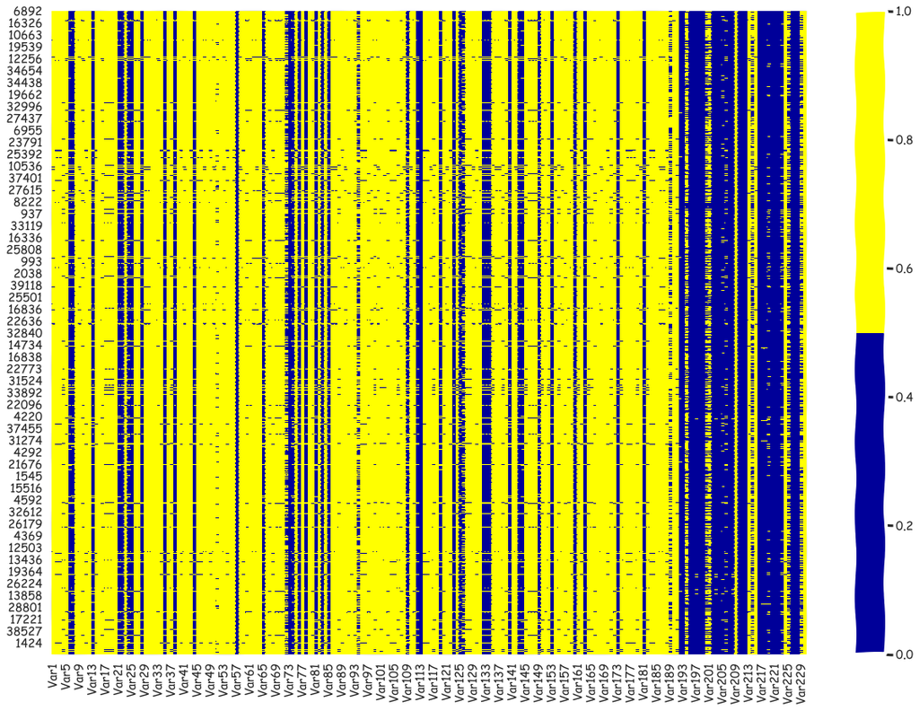

```python
def null_map(data):
    data_to_heat = data.isnull()
    data_to_heat.head()
    with plt.xkcd():
        plt.figure(figsize=(20,14))
        colors = ['#000099', '#ffff00']
        sns.heatmap(data_to_heat,cmap = sns.color_palette(colors));
null_map(feats_train)
```

Можно заметить огромное количество пропусков (желтым).

Загрузим все необходимые функции и классы

```python
def feat_classif_clean_nan(data,prop_nan=0.3,len_uniq_num_min=20,len_uniq_min=2):

    #Функция первичного отбора (по NaN) и классификации признаков (категориальные или числовые),
    #можем менять допустимую долю NaN - prop_nan, а также пороговые количества уникальных значений
    #Возвращает списки с названиями столбцов

    #Обработка числовых признаков
    data_float = data.select_dtypes(include = ['float64'],).copy()

    cols_float_cat = []
    cols_float_num = []
    for col in data_float.columns:
        # Удаляем рассмотрения признаки,где доля nan больше prop_nan
        if data[col].dropna().shape[0]/data[col].shape[0] > 1-prop_nan:
            len_unique = np.unique(data[col].dropna()).shape[0]
            if len_unique <= len_uniq_num_min:#порог для отнесения числового признака к категориальным
                if len_unique >= len_uniq_min:
                    cols_float_cat.append(col)
            else:
                cols_float_num.append(col)


    #Обработка нечисловых признаков
    data_not_num = data.select_dtypes(include=['object']).copy()

    cols_cat=[]
    for col in data_not_num.columns.tolist():
        # Удаляем из рассмотрения признаки,где доля nan  больше prop_nan
        if data[col].dropna().shape[0]/data[col].shape[0] > 1-prop_nan:
            len_unique = np.unique(data[col].dropna()).shape[0]
            if len_unique >= len_uniq_min:
                cols_cat.append(col)

    num_columns = cols_float_num+['Var73'] #числовые признаки
    cat_columns = cols_cat+cols_float_cat #категориальные признаки

    return num_columns,cat_columns
```

```python
def fe_cat_clean_too_high_cardinality(data,cat_columns,max_prop_unique=1):
    #Удаляем неинформативные признаки (слишком много категорий,
    # доля уникальных из заполненных приближается к max_prop_unique)
    #Возвращает список с названиями столбцов
    cat_features = data[cat_columns].copy()
    cat_columns_new = []

    for col in cat_columns:
        level_counts = cat_features[col].value_counts()
        #Проверяем условие не слишком большого числа категорий (доля от количества объектов - max_prop_unique)
        if level_counts.shape[0]/level_counts.sum() < max_prop_unique:
            cat_columns_new.append(col)#добавляем признак

    return cat_columns_new
```

```python
def fe_cat_cardinality_classification(data,cat_columns,N_lim=10):
    #Классифицируем категориальные признаки по количеству категорий
     #Возвращает списки с названиями столбцов
    cat_features = data[cat_columns].copy()

    low_cardinality_columns = []
    high_cardinality_columns = []
    for col in cat_columns:
        if cat_features[col].unique().shape[0] < N_lim:
            low_cardinality_columns.append(col)
        else:
            high_cardinality_columns.append(col)

    return low_cardinality_columns, high_cardinality_columns
```

```python
def data_preprocessor(data,params):
    #return indices fo each category

    data=data.copy()
    [prop_nan,max_prop_unique,N_lim] = params


    numeric_data_columns,categorical_data_columns0 = feat_classif_clean_nan(data,prop_nan=prop_nan)
    numeric_data_indices = np.array([(column in numeric_data_columns) for column in data.columns], dtype = bool)


    categorical_data_columns = fe_cat_clean_too_high_cardinality(data,categorical_data_columns0,max_prop_unique=max_prop_unique)

    low_cardinality_cat_columns ,high_cardinality_cat_columns = fe_cat_cardinality_classification(data,\
                                                                                              categorical_data_columns,N_lim=N_lim)
    low_card_cat_data_indices = np.array([(column in low_cardinality_cat_columns) for column in data.columns], dtype = bool)
    high_card_cat_data_indices = np.array([(column in high_cardinality_cat_columns) for column in data.columns], dtype = bool)


    indices_lists = [numeric_data_indices,low_card_cat_data_indices,high_card_cat_data_indices]
    return indices_lists
```

```python
class MyCatMergerNaInputer(BaseEstimator, TransformerMixin):


    def __init__(self,occurrence_med_prop = 0.2,fill_value='NaN'):
        self.fill_value = fill_value
        self.var_cat_dict = {}
        self.occurrence_med_prop = occurrence_med_prop


    def fit(self,X,y=None):

        df = pd.DataFrame(X)
        df = df.fillna(self.fill_value)
        df = pd.DataFrame(df,dtype=str)

        for col in df.columns:
            level_counts = df[col].value_counts()
            lvl_c_median_norm = level_counts/level_counts.median()
            small_cat_list = lvl_c_median_norm[lvl_c_median_norm < self.occurrence_med_prop].index
            self.var_cat_dict[col] = small_cat_list

        return self


    def transform(self,X,y=None):

        df = pd.DataFrame(X)
        df = df.fillna(self.fill_value)
        df = pd.DataFrame(df,dtype=str)

        for col in df.columns:
            df[col] = df[col].apply(lambda x: f'{col}_other_cat' if x in self.var_cat_dict[col] else x)

        return df.values
```

```python
def transformation(low_level_transformers,indices_lists):
    [numeric_imputer,numeric_scaler,cat_imputer1,cat_imputer2,\
                low_cardinality_cat_transformer,high_cardinality_cat_transformer] = low_level_transformers
    [numeric_data_indices,low_card_cat_data_indices,high_card_cat_data_indices] = indices_lists
    return pipeline.FeatureUnion(transformer_list =[
    #numeric
    ('numeric_features_processing', pipeline.Pipeline(steps = [
    ('selecting', preprocessing.FunctionTransformer(lambda data: data[:, numeric_data_indices])),
    ('fill_nan',numeric_imputer),
    ('scaling', numeric_scaler)
                        ])),
    #categorical
    ('cat_features_processing', pipeline.FeatureUnion(transformer_list =[
        #number of categories < N_lim
        ('low_cardinality_transformation', pipeline.Pipeline(steps = [
                ('selecting', preprocessing.FunctionTransformer(lambda data: data[:, low_card_cat_data_indices])),
                ('fill_nan',cat_imputer1 ),
                ('low_cardinality_cat_transformer', low_cardinality_cat_transformer)
                        ])),
        #number of categories >= N_lim
        ('high_cardinality_transformation', pipeline.Pipeline(steps = [
                ('selecting', preprocessing.FunctionTransformer(lambda data: data[:, high_card_cat_data_indices])),
                ('fill_nan',cat_imputer2 ),
                ('high_cardinality_cat_transformer', high_cardinality_cat_transformer)
                        ]))
    ]))

])
```

```python
class Estimator(BaseEstimator, TransformerMixin):

    def __init__(self, transformer,classifier):
        self.transformer = transformer
        self.classifier = classifier

    def fit(self, X, y):
        self.transformer.fit(X,y)
        X_tr = self.transformer.transform(X)
        self.classifier.fit(X_tr,y)
        return self.classifier

    def predict(self, X):
        X_tr = self.transformer.transform(X)
        return self.classifier.predict(X_tr)

    def predict_proba(self,X):
        X_tr = self.transformer.transform(X)
        return self.classifier.predict_proba(X_tr)
```

```python
def pr_plot(y_true,probs, thrshs):
    #Функция для визуализации результатов

    precisions=[]
    recalls=[]
    thrshs=thrshs
    for threshold in thrshs:
        y_pred = [1 if prob > threshold else -1 for prob in probs[:,1]]
        precisions.append(precision_score(y_true,y_pred))
        recalls.append(recall_score(y_true,y_pred))

    with plt.xkcd():
        plt.plot(thrshs, precisions,label='precision');
        plt.plot(thrshs, recalls,label='recall');
        plt.xlabel('threshold')
        plt.legend()
        plt.title('Зависимость значений метрик от порога')
        plt.grid()
        plt.ylabel('metric');
```

```python
def write_to_submission_file(predicted_labels, out_file,
                             target='result', index_label="Id"):
    # turn predictions into data frame and save as csv file
    predicted_df = pd.DataFrame(predicted_labels,
                                index = np.arange(0, predicted_labels.shape[0]),
                                columns=[target])
    predicted_df.to_csv(out_file, index_label=index_label)
```

Сделаем предобработку, результатом будут индексы значимых признаков.

```python
%%time
indices_lists = data_preprocessor(feats_train,params=[0.7, 0.5, 30])
indices_lists
```

```
Wall time: 1.89 s
```

```
[array([False, False, False, False, False,  True, False, False, False,
        False, False, False,  True, False, False, False, False, False,
        False, False,  True,  True, False,  True,  True, False, False,
         True, False, False, False, False, False, False, False, False,
        False,  True, False, False, False, False, False, False, False,
        False, False, False, False, False, False, False, False, False,
        False, False,  True, False, False, False, False, False, False,
        False, False, False, False, False, False, False, False, False,
         True,  True, False,  True, False, False, False, False,  True,
        False,  True, False,  True, False, False, False, False, False,
        False, False, False,  True, False, False, False, False, False,
        False, False, False, False, False, False, False, False, False,
         True, False, False,  True,  True, False, False, False, False,
        False,  True, False, False, False,  True, False,  True,  True,
        False, False, False, False, False, False,  True,  True, False,
        False, False, False, False,  True, False, False, False, False,
        False, False, False, False,  True, False, False, False,  True,
        False, False, False, False, False, False,  True, False, False,
         True, False, False, False, False, False, False, False, False,
        False, False, False, False, False, False, False, False, False,
        False, False, False, False, False, False, False, False,  True,
        False, False, False, False, False, False, False, False, False,
        False, False, False, False, False, False, False, False, False,
        False, False, False, False, False, False, False, False, False,
        False, False, False, False, False, False, False, False, False,
        False, False, False, False, False]),
 array([False, False, False, False, False, False,  True, False, False,
        False, False, False, False, False, False, False, False, False,
        False, False, False, False, False, False, False, False, False,
        False, False, False, False, False, False, False,  True, False,
        False, False, False, False, False, False, False,  True, False,
        False, False, False, False, False, False, False, False, False,
        False, False, False, False, False, False, False, False, False,
        False,  True, False, False, False, False, False, False,  True,
        False, False, False, False, False,  True, False, False, False,
        False, False, False, False, False, False, False, False, False,
        False, False, False, False, False, False, False, False, False,
        False, False, False, False, False, False, False, False, False,
        False, False, False, False, False, False, False, False, False,
        False, False, False, False, False, False, False, False, False,
```

[output cut: 23 more lines]

```
        False, False, False, False, False, False, False, False, False,
        False, False, False, False, False, False, False, False, False,
        False, False, False, False, False, False, False, False, False,
        False, False, False, False, False, False, False, False, False,
        False, False, False, False, False, False, False, False, False,
        False, False, False, False, False, False, False, False, False,
        False, False, False, False, False, False, False, False, False,
        False, False, False, False, False, False, False, False, False,
        False, False, False, False, False, False, False, False, False,
        False, False, False, False, False, False, False, False, False,
        False, False,  True,  True, False, False, False,  True,  True,
         True, False, False,  True, False,  True, False, False, False,
        False, False, False, False,  True, False, False, False,  True,
         True, False, False,  True, False,  True, False, False, False,
        False, False,  True, False, False])]
```

Зададим трансформер и классификатор, а затем обучим и покажем результат в соревновании

```python
occurrence_med_prop = 0.1

numeric_imputer = impute.SimpleImputer()
numeric_scaler = None
cat_imputer1 =  MyCatMergerNaInputer(occurrence_med_prop = occurrence_med_prop,fill_value='Hi')
cat_imputer2 =  MyCatMergerNaInputer(occurrence_med_prop = occurrence_med_prop,fill_value='Hi')
low_cardinality_cat_transformer=preprocessing.OneHotEncoder(handle_unknown = 'ignore')
high_cardinality_cat_transformer=BinaryEncoder()


low_level_transformers = [numeric_imputer,numeric_scaler,cat_imputer1,cat_imputer2,\
                low_cardinality_cat_transformer,high_cardinality_cat_transformer]

transformer = transformation(low_level_transformers,indices_lists)
```

```python
clf_res = xgb.XGBClassifier(random_state=42,n_estimators=100,gamma=0.1,max_depth=3,reg_alpha=1)
```

```
XGBClassifier(base_score=0.5, booster='gbtree', colsample_bylevel=1,
              colsample_bynode=1, colsample_bytree=1, gamma=0.1,
              learning_rate=0.1, max_delta_step=0, max_depth=3,
              min_child_weight=1, missing=None, n_estimators=100, n_jobs=1,
              nthread=None, objective='binary:logistic', random_state=42,
              reg_alpha=1, reg_lambda=1, scale_pos_weight=1, seed=None,
              silent=None, subsample=1, verbosity=1)
```

```
ROC AUC: 0.7392341885422578
PRC AUC: 0.20791665603990814
              precision    recall  f1-score   support

          -1       0.93      1.00      0.96     11107
           1       0.50      0.01      0.01       893

    accuracy                           0.93     12000
   macro avg       0.71      0.50      0.49     12000
weighted avg       0.89      0.93      0.89     12000

------------------
------------------
```

```
Wall time: 30 s
```

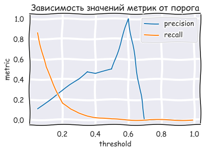

```python
%%time
print(clf_res)
est = Estimator(transformer,clf_res)
est.fit(feats_train.values,labels_train.values)
prb = est.predict_proba(feats_val.values)

print(f'ROC AUC: {roc_auc_score(labels_val.values,prb[:,1])}')
print(f'PRC AUC: {average_precision_score(labels_val.values,prb[:,1])}')

pred = est.predict(feats_val.values)
print(classification_report(labels_val.values,pred))
print('------------------')
print('------------------')

pr_plot(labels_val.values,prb,[0.05,0.1,0.2,0.25,0.3,0.35,0.4,0.5,0.6,0.7,0.8,0.9,0.95,0.96,0.97,0.99])
```

```python
test_data = pd.read_csv('orange_small_churn_test_data.csv', index_col='ID')
test_data.head()
```

| ID | Var1 | Var2 | Var3 | Var4 | Var5 | Var6 | Var7 | Var8 | Var9 | Var10 | ... | Var221 | Var222 | Var223 | Var224 | Var225 | Var226 | Var227 | Var228 | Var229 | Var230 |
| --- | --- | --- | --- | --- | --- | --- | --- | --- | --- | --- | --- | --- | --- | --- | --- | --- | --- | --- | --- | --- | --- |
| 0 | NaN | NaN | NaN | NaN | NaN | 1225.0 | 7.0 | NaN | NaN | NaN | ... | zCkv | APgdzOv | jySVZNlOJy | NaN | ELof | xb3V | 6fzt | Zy3gnGM | NaN | NaN |
| 1 | NaN | NaN | NaN | NaN | NaN | 896.0 | 14.0 | NaN | NaN | NaN | ... | oslk | IIvC99a | LM8l689qOp | NaN | NaN | xb3V | RAYp | F2FyR07IdsN7I | NaN | NaN |
| 2 | NaN | NaN | NaN | NaN | NaN | 791.0 | 7.0 | NaN | NaN | NaN | ... | oslk | 6YSocsg | LM8l689qOp | NaN | kG3k | rgKb | RAYp | F2FyR07IdsN7I | mj86 | NaN |
| 3 | NaN | NaN | NaN | NaN | NaN | 2296.0 | 7.0 | NaN | NaN | NaN | ... | oslk | 5nQ7A2G | jySVZNlOJy | NaN | kG3k | rgKb | RAYp | F2FyR07IdsN7I | am7c | NaN |
| 4 | 8.0 | NaN | NaN | NaN | NaN | NaN | NaN | NaN | 28.0 | NaN | ... | oslk | MI8s5nE | LM8l689qOp | NaN | NaN | 7P5s | RAYp | F2FyR07IdsN7I | NaN | NaN |

5 rows × 230 columns

```python
%%time
estimator = Estimator(transformer,clf_res)

estimator.fit(features.values,labels.values)
probs = estimator.predict_proba(test_data.values)
write_to_submission_file(probs[:,1],out_file='submission3.csv')
```

```
Wall time: 36.5 s
```

[figure not shown]

### 1. Эксперименты с моделью

**Вступление из задания:**

На прошлой неделе вы поучаствовали в соревновании на kaggle и, наверняка, большинство успешно справилось с прохождением baseline, а значит пора двигаться дальше - заняться оптимизацией модели, провести серию экспериментов и построить сильное финальное решения.

В этом задании вам нужно провести ряд эскпериментов, оценить качество полученных в процессе экспериментирования моделей и выбрать лучшее решение.

Задание будет оцениваться на основании загруженного jupyther notebook и развернутых ответов на поставленные вопросы.

### Инструкции

1. Начнем с простого. Давайте оценим как много объектов действительно нужно для построения качественной модели. Для обучения доступна достаточно большая выборка и может так оказаться, что начиная с некоторого момента рост размера обучающей выборки перестает влиять на качество модели. Постройте кривые обучения, обучая модель на выборках разного размера начиная с небольшого количество объектов в обучающей выборке и постепенно наращивая её размер с некоторым шагом. Обратите внимание на `sklearn.model_selection.learning_curve`

```python
from sklearn.model_selection import learning_curve
```

```python
def plot_learning_curve(val_train, val_test, train_sizes,
                        xlabel='Training Set Size', ylabel='score'):
    def plot_with_err(x, data, **kwargs):
        mu, std = data.mean(1), data.std(1)
        lines = plt.plot(x, mu, '-', **kwargs)
        plt.fill_between(x, mu - std, mu + std, edgecolor='none',
                         facecolor=lines[0].get_color(), alpha=0.2)
    plot_with_err(train_sizes, val_train, label='train')
    plot_with_err(train_sizes, val_test, label='valid')
    plt.xlabel(xlabel); plt.ylabel(ylabel)
    plt.legend(loc='lower right');
```

```python
skf = StratifiedKFold(n_splits=7, shuffle=True, random_state=17)
```

```
Wall time: 4min 52s
```

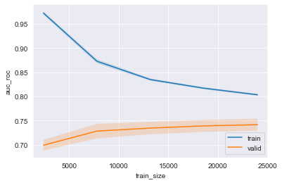

```python
%%time
n_train,val_train, val_test= learning_curve(estimator, feats_train.values,labels_train.values,cv=skf,scoring='roc_auc',random_state=17,n_jobs=-1)
plot_learning_curve(val_train, val_test, n_train, xlabel='train_size', ylabel='auc_roc')
```

Анализируя кривые обучения по AUC ROC, видно, что качество на валидации перестает существенно расти уже после 20000 объектов, хотя в соревновании каждая доля процента важна.

```python
from sklearn.metrics import make_scorer
scorer_prc = make_scorer(average_precision_score,needs_proba=True)
```

```
Wall time: 5min 44s
```

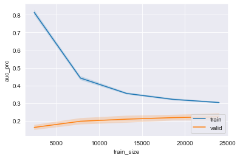

```python
%%time
n_train,val_train, val_test= learning_curve(estimator, feats_train.values,labels_train.values,cv=skf,scoring=scorer_prc,random_state=17,n_jobs=-1)
plot_learning_curve(val_train, val_test, n_train, xlabel='train_size', ylabel='auc_prc')
```

Анализируя кривые обучения по AUC PRC, видно, что качество на валидации также перестает существенно расти уже после 20000 объектов.

2. Часто несбалансированные по классам выборки приводят к различным проблемам при обучении моделей. Давайте попробуем по-разному обработать выборку, поиграть с распределением объектов по классам и сделать выводы о том, как соотношение классов влияет на качество модели.

2.1. Задайте веса объектам так, чтобы соотношение классов с учетом весов объектов изменилось. Попробуйте не менее трёх различных вариантов весов. Меняются ли результаты классификации? Как это сказывается на качестве модели? Какой вариант выглядит наиболее оптимальным с точки зрения качества?

```python
sum(labels.target==-1) / sum(labels.target==1)
```

```
12.440860215053764
```

```python
%%time
for scale in [1,6,7,8,12.44,15]:
    clf = xgb.XGBClassifier(random_state=42,n_estimators=100,gamma=0.1,max_depth=3,reg_alpha=1, scale_pos_weight=scale)
    estimator = Estimator(transformer,clf)
    score_mean = cross_val_score(estimator,feats_train.values,labels_train.values,cv=skf,\
                             scoring='roc_auc',n_jobs=-1).mean()
    print(f'average score with scale = {scale}: {score_mean}')
```

```
average score with scale = 1: 0.7416260915625011
average score with scale = 6: 0.7393222348003866
average score with scale = 7: 0.7394874295278597
average score with scale = 8: 0.737709875472679
average score with scale = 12.44: 0.7360361996862602
average score with scale = 15: 0.7339725260733337
Wall time: 10min 39s
```

```python
%%time
for scale in [0.1,0.2,0.3,0.4,0.5,1]:
    clf = xgb.XGBClassifier(random_state=42,n_estimators=100,gamma=0.1,max_depth=3,reg_alpha=1, scale_pos_weight=scale)
    estimator = Estimator(transformer,clf)
    score_mean = cross_val_score(estimator,feats_train.values,labels_train.values,cv=skf,\
                             scoring='roc_auc',n_jobs=-1).mean()
    print(f'average score with scale = {scale}: {score_mean}')
```

```
average score with scale = 0.1: 0.7388962816855574
average score with scale = 0.2: 0.7401334932039385
average score with scale = 0.3: 0.7411954582055491
average score with scale = 0.4: 0.7422033184063362
average score with scale = 0.5: 0.7424652578660627
average score with scale = 1: 0.7416260915625011
Wall time: 10min 58s
```

```python
%%time
for scale in [0.5,0.55,0.6,0.65,0.7,0.8]:
    clf = xgb.XGBClassifier(random_state=42,n_estimators=100,gamma=0.1,max_depth=3,reg_alpha=1, scale_pos_weight=scale)
    estimator = Estimator(transformer,clf)
    scores = cross_val_score(estimator,feats_train.values,labels_train.values,cv=skf,\
                             scoring='roc_auc',n_jobs=-1)
    score_mean = scores.mean()
    score_std = scores.std()

    print(f'average score with scale = {scale}: {score_mean}, standard deviation: {score_std}')
```

```
average score with scale = 0.5: 0.7424652578660627, standard deviation: 0.014103769339900596
average score with scale = 0.55: 0.7432443514692952, standard deviation: 0.014722642532963747
average score with scale = 0.6: 0.7426948828614861, standard deviation: 0.012778756035437417
average score with scale = 0.65: 0.7417246289882743, standard deviation: 0.015314022938719226
average score with scale = 0.7: 0.7416571009308746, standard deviation: 0.01353885911842071
average score with scale = 0.8: 0.742321494839267, standard deviation: 0.01363369617833546
Wall time: 10min 30s
```

```python
%%time
for scale in [0.5,1,15]:
    clf = xgb.XGBClassifier(random_state=42,n_estimators=100,gamma=0.1,max_depth=3,reg_alpha=1, scale_pos_weight=scale)
    estimator = Estimator(transformer,clf)
    scores = cross_val_score(estimator,feats_train.values,labels_train.values,cv=skf,\
                             scoring=scorer_prc,n_jobs=-1)
    score_mean = scores.mean()
    score_std = scores.std()

    print(f'average score with scale = {scale}: {score_mean}, standard deviation: {score_std}')
```

```
average score with scale = 0.5: 0.22119796107748396, standard deviation: 0.018206933834802225
average score with scale = 1: 0.22263754524569826, standard deviation: 0.019773794116944413
average score with scale = 15: 0.2091705648516569, standard deviation: 0.01927394165784406
Wall time: 4min 55s
```

Как ни странно, но уменьшение веса положительного класса до 0.55 несколько улучшило качество, хотя данное явление незначительно, на мой взгляд. А вот обратная операция качество уменьшила более существенно, падение около 1 процента.

```python
%%time
clf_res = xgb.XGBClassifier(random_state=42,n_estimators=100,gamma=0.1,max_depth=3,reg_alpha=1, scale_pos_weight=0.55)
estimator = Estimator(transformer,clf_res)

estimator.fit(features.values,labels.values)
probs = estimator.predict_proba(test_data.values)
write_to_submission_file(probs[:,1],out_file='submission4.csv')
```

```
Wall time: 45.9 s
```

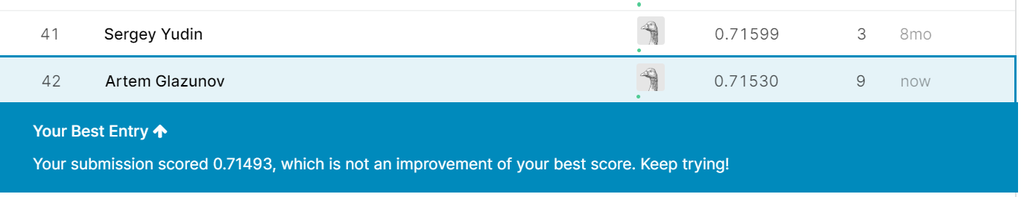

Видно, что улучшения в соревновании данная операция не дала

2.2. Примените к выборке технологию undersampling: для этого нужно убрать из обучения некоторое количество объектов большего класса таким образом, чтобы соотношение классов изменилось. Попробуйте не менее трёх различных вариантов undersampling (варианты могут отличаться как по количество отфильтрованных объектов, так и по принципу выборка объектов для отсеивания из выборки). Меняются ли результаты классификации? Как это сказывается на качестве модели? Какой вариант выглядит наиболее оптимальным с точки зрения качества?

```python
from imblearn.under_sampling import RandomUnderSampler
```

```python
sum(labels.target==1) / sum(labels.target==-1)
```

```
0.08038029386343994
```

```python
from imblearn.under_sampling import RandomUnderSampler
rus = RandomUnderSampler(random_state=42)
X_resampled, y_resampled = rus.fit_resample(feats_train.values,labels_train.values)
```

```python
sum(y_resampled==-1)/sum(y_resampled==1)
```

```
1.0
```

```python
clf = xgb.XGBClassifier(random_state=42,n_estimators=100,gamma=0.1,max_depth=3,reg_alpha=1)
estimator = Estimator(transformer,clf)
scores = cross_val_score(estimator,X_resampled, y_resampled,cv=skf,\
                             scoring='roc_auc',n_jobs=-1)
score_mean = scores.mean()
score_std = scores.std()
print(score_mean,score_std)
```

```
0.608115837204617 0.02376050785076366
```

```python
for ratio in [0.2,0.3,0.5,0.6]:
    rus = RandomUnderSampler(sampling_strategy=ratio,random_state=42)
    X_resampled, y_resampled = rus.fit_resample(feats_train.values,labels_train.values)
    clf = xgb.XGBClassifier(random_state=42,n_estimators=100,gamma=0.1,max_depth=3,reg_alpha=1)
    estimator = Estimator(transformer,clf)
    scores = cross_val_score(estimator,X_resampled, y_resampled,cv=skf,\
                             scoring='roc_auc',n_jobs=-1)
    score_mean = scores.mean()
    score_std = scores.std()
    print(f'ration: {ratio}, score mean: {score_mean}, score std: {score_std}')
```

```
ration: 0.2, score mean: 0.7009978365342444, score std: 0.010596227910148432
ration: 0.3, score mean: 0.6795766830667784, score std: 0.0189286295151926
ration: 0.5, score mean: 0.6586706067417815, score std: 0.013503500755384357
ration: 0.6, score mean: 0.6378392448151865, score std: 0.009237480096407139
```

```python
for ratio in [0.09,0.095,0.15]:
    rus = RandomUnderSampler(sampling_strategy=ratio,random_state=42)
    X_resampled, y_resampled = rus.fit_resample(feats_train.values,labels_train.values)
    clf = xgb.XGBClassifier(random_state=42,n_estimators=100,gamma=0.1,max_depth=3,reg_alpha=1)
    estimator = Estimator(transformer,clf)
    scores = cross_val_score(estimator,X_resampled, y_resampled,cv=skf,\
                             scoring='roc_auc',n_jobs=-1)
    score_mean = scores.mean()
    score_std = scores.std()
    print(f'ration: {ratio}, score mean: {score_mean}, score std: {score_std}')
```

```
ration: 0.09, score mean: 0.7244330083444303, score std: 0.0073116075528123926
ration: 0.095, score mean: 0.7221224061889898, score std: 0.015181113314412402
ration: 0.15, score mean: 0.7132505693286779, score std: 0.010020062799606879
```

Видно, что при использовании данной стратегии качество на кроссвалидации ухудшается. Но, учитывая кривые обучения, попробуем обучить на всей тренировочной выборке и проверить на валидационной выборке.

```
ROC AUC: 0.726710837097072
PRC AUC: 0.1720533369443954
              precision    recall  f1-score   support

          -1       0.93      0.99      0.96     11107
           1       0.13      0.02      0.04       893

    accuracy                           0.92     12000
   macro avg       0.53      0.50      0.50     12000
weighted avg       0.87      0.92      0.89     12000

------------------
------------------
```

```
ROC AUC: 0.7253538344461807
PRC AUC: 0.1704741894040189
              precision    recall  f1-score   support

          -1       0.93      0.99      0.96     11107
           1       0.18      0.03      0.04       893

    accuracy                           0.92     12000
   macro avg       0.55      0.51      0.50     12000
weighted avg       0.87      0.92      0.89     12000

------------------
------------------
```

```
ROC AUC: 0.7117410093470306
PRC AUC: 0.16248563008091207
              precision    recall  f1-score   support

          -1       0.93      0.98      0.95     11107
           1       0.19      0.05      0.09       893

    accuracy                           0.91     12000
   macro avg       0.56      0.52      0.52     12000
weighted avg       0.87      0.91      0.89     12000

------------------
------------------
```

```
ROC AUC: 0.7024681831045685
PRC AUC: 0.15099261009461462
              precision    recall  f1-score   support

          -1       0.93      0.97      0.95     11107
           1       0.18      0.08      0.11       893

    accuracy                           0.91     12000
   macro avg       0.56      0.52      0.53     12000
weighted avg       0.87      0.91      0.89     12000

------------------
------------------
```

```
Wall time: 2min 50s
```

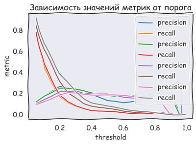

```python
%%time
for ratio in [0.09,0.095,0.15,0.2]:
    rus = RandomUnderSampler(sampling_strategy=ratio,random_state=42)
    X_resampled, y_resampled = rus.fit_resample(feats_train.values,labels_train.values)
    clf = xgb.XGBClassifier(random_state=42,n_estimators=100,gamma=0.1,max_depth=3,reg_alpha=1)
    est = Estimator(transformer,clf)
    est.fit(X_resampled, y_resampled)
    prb = est.predict_proba(feats_val.values)

    print(f'ROC AUC: {roc_auc_score(labels_val.values,prb[:,1])}')
    print(f'PRC AUC: {average_precision_score(labels_val.values,prb[:,1])}')

    pred = est.predict(feats_val.values)
    print(classification_report(labels_val.values,pred))
    print('------------------')
    print('------------------')

    pr_plot(labels_val.values,prb,[0.05,0.1,0.2,0.25,0.3,0.35,0.4,0.5,0.6,0.7,0.8,0.9,0.95,0.96,0.97,0.99])
```

```
ROC AUC: 0.7392341885422578
PRC AUC: 0.20791665603990814
              precision    recall  f1-score   support

          -1       0.93      1.00      0.96     11107
           1       0.50      0.01      0.01       893

    accuracy                           0.93     12000
   macro avg       0.71      0.50      0.49     12000
weighted avg       0.89      0.93      0.89     12000

------------------
------------------
```

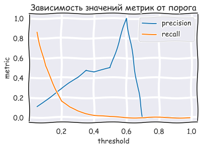

```python
clf = xgb.XGBClassifier(random_state=42,n_estimators=100,gamma=0.1,max_depth=3,reg_alpha=1)
est = Estimator(transformer,clf)
est.fit(feats_train.values,labels_train.values)
prb = est.predict_proba(feats_val.values)

print(f'ROC AUC: {roc_auc_score(labels_val.values,prb[:,1])}')
print(f'PRC AUC: {average_precision_score(labels_val.values,prb[:,1])}')

pred = est.predict(feats_val.values)
print(classification_report(labels_val.values,pred))
print('------------------')
print('------------------')

pr_plot(labels_val.values,prb,[0.05,0.1,0.2,0.25,0.3,0.35,0.4,0.5,0.6,0.7,0.8,0.9,0.95,0.96,0.97,0.99])
```

Но все же проверим в соревновании с коэффициентом 0.15

```python
%%time
rus = RandomUnderSampler(sampling_strategy=0.15,random_state=42)
X_resampled, y_resampled = rus.fit_resample(features.values,labels.values)
clf_res = xgb.XGBClassifier(random_state=42,n_estimators=100,gamma=0.1,max_depth=3,reg_alpha=1)
estimator = Estimator(transformer,clf_res)

estimator.fit(X_resampled, y_resampled)
probs = estimator.predict_proba(test_data.values)
write_to_submission_file(probs[:,1],out_file='submission7.csv')
```

```
Wall time: 44.5 s
```

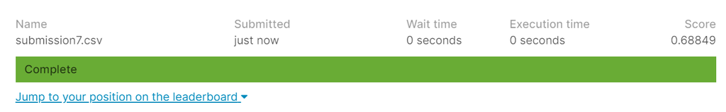

Видна корреляция между результатами кросс-валидации, результатами на валидационной выборке, а также в соревновании.

Итак, данная стратегия ухудшает качество, не будем ею пользоваться.

Попробуем применить обратную стратегию, oversampling. Результаты должны быть близкие к тем, которые были получены в п. 2.1, поскольку подходы близки.

```python
from imblearn.over_sampling import RandomOverSampler
ros = RandomOverSampler(random_state=0)
X_resampled, y_resampled = ros.fit_resample(feats_train.values,labels_train.values)
clf = xgb.XGBClassifier(random_state=42,n_estimators=100,gamma=0.1,max_depth=3,reg_alpha=1)
estimator = Estimator(transformer,clf)
scores = cross_val_score(estimator,X_resampled, y_resampled,cv=skf,\
                             scoring='roc_auc',n_jobs=-1)
score_mean = scores.mean()
score_std = scores.std()
print(score_mean,score_std)
```

```
0.8090236717522988 0.005009926753694075
```

```python
sum(y_resampled==-1)/sum(y_resampled==1)
```

```
1.0
```

```python
y_resampled.shape[0]/labels_train.shape[0]
```

```
1.8512142857142857
```

```python
for ratio in [0.1,0.2,0.5,0.6,0.7,0.8]:
    ros = RandomOverSampler(sampling_strategy=ratio,random_state=0)
    X_resampled, y_resampled = ros.fit_resample(feats_train.values,labels_train.values)
    clf = xgb.XGBClassifier(random_state=42,n_estimators=100,gamma=0.1,max_depth=3,reg_alpha=1)
    estimator = Estimator(transformer,clf)
    scores = cross_val_score(estimator,X_resampled, y_resampled,cv=skf,\
                             scoring='roc_auc',n_jobs=-1)
    score_mean = scores.mean()
    score_std = scores.std()
    print(f'ratio: {ratio}, score mean: {score_mean}, score std: {score_std}')
```

```
ratio: 0.1, score mean: 0.759852122522556, score std: 0.007876286717363085
ratio: 0.2, score mean: 0.8004307091970279, score std: 0.009400252353319979
ratio: 0.5, score mean: 0.8118240653879509, score std: 0.006352739299860881
ratio: 0.6, score mean: 0.8105146724572865, score std: 0.0038330241952556437
ratio: 0.7, score mean: 0.8093108635923915, score std: 0.0053013353020635616
ratio: 0.8, score mean: 0.8084257928559764, score std: 0.006015553667600935
```

```python
for ratio in [0.25,0.3,0.35,0.4,0.45,0.55]:
    ros = RandomOverSampler(sampling_strategy=ratio,random_state=0)
    X_resampled, y_resampled = ros.fit_resample(feats_train.values,labels_train.values)
    clf = xgb.XGBClassifier(random_state=42,n_estimators=100,gamma=0.1,max_depth=3,reg_alpha=1)
    estimator = Estimator(transformer,clf)
    scores = cross_val_score(estimator,X_resampled, y_resampled,cv=skf,\
                             scoring='roc_auc',n_jobs=-1)
    score_mean = scores.mean()
    score_std = scores.std()
    print(f'ratio: {ratio}, score mean: {score_mean}, score std: {score_std}')
```

```
ratio: 0.25, score mean: 0.8057181603874183, score std: 0.007406717400462506
ratio: 0.3, score mean: 0.8096407996622031, score std: 0.0030066787774052106
ratio: 0.35, score mean: 0.8091990810705639, score std: 0.011403885282064328
ratio: 0.4, score mean: 0.8098359970444939, score std: 0.0067087856319922885
ratio: 0.45, score mean: 0.810473187218208, score std: 0.007769357257539924
ratio: 0.55, score mean: 0.8103804504224293, score std: 0.007294275551007564
```

Получили очень высокое качество на кроссвалидации с узкими доверительными интервалами. Проверим в соревновании.

```python
%%time
ros = RandomOverSampler(sampling_strategy=0.5,random_state=0)
X_resampled, y_resampled = ros.fit_resample(features.values,labels.values)

clf_res = xgb.XGBClassifier(random_state=42,n_estimators=100,gamma=0.1,max_depth=3,reg_alpha=1)
estimator = Estimator(transformer,clf_res)

estimator.fit(X_resampled, y_resampled)
probs = estimator.predict_proba(test_data.values)
write_to_submission_file(probs[:,1],out_file='submission6.csv')
```

```
Wall time: 1min 38s
```

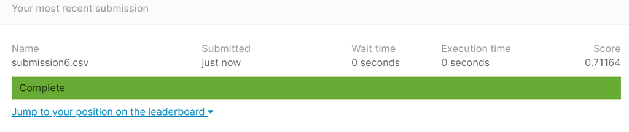

Так почему же кросс-валидация дала такой неверный результат? Если задуматься о том, что происходит, то можно увидеть утечку данных из тренировочных в тестовые фолды. Действительно, при таком подходе к сэмлированию, получается много дубликатов, они случайным образом попадают в тестовые фолды и улучшают качество. Тогда, чтобы корректно подходить к кроссвалидации, работу по репликации меньшего класса нужно проводить при каждом разбиении. Для этих целей написан следующий класс.

```python
class OverSamplerEstimator(BaseEstimator, TransformerMixin):

    def __init__(self, oversampler,estimator):
        self.oversampler = oversampler
        self.estimator = estimator

    def fit(self, X, y):
        X_resampled, y_resampled = self.oversampler.fit_resample(X,y)
        self.estimator.fit(X_resampled, y_resampled)
        return self.estimator

    def predict(self, X):
        return self.estimator.predict(X)

    def predict_proba(self,X):
        return self.estimator.predict_proba(X)
```

```python
ratio='auto'
ros = RandomOverSampler(sampling_strategy=ratio,random_state=0)
clf = xgb.XGBClassifier(random_state=42,n_estimators=100,gamma=0.1,max_depth=3,reg_alpha=1)
estimator = Estimator(transformer,clf)

experimental_est=OverSamplerEstimator(ros,estimator)
experimental_est
```

[output not shown]

```
ROC AUC: 0.7318312422852895
PRC AUC: 0.19638648457773325
              precision    recall  f1-score   support

          -1       0.96      0.69      0.81     11107
           1       0.14      0.64      0.24       893

    accuracy                           0.69     12000
   macro avg       0.55      0.67      0.52     12000
weighted avg       0.90      0.69      0.76     12000

------------------
------------------
```

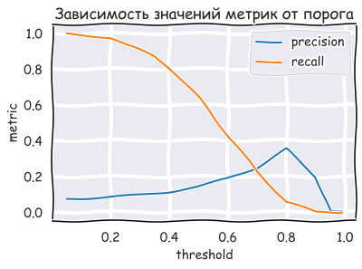

```python
experimental_est.fit(feats_train.values,labels_train.values)

prb = estimator.predict_proba(feats_val.values)

print(f'ROC AUC: {roc_auc_score(labels_val.values,prb[:,1])}')
print(f'PRC AUC: {average_precision_score(labels_val.values,prb[:,1])}')

pred = estimator.predict(feats_val.values)
print(classification_report(labels_val.values,pred))
print('------------------')
print('------------------')

pr_plot(labels_val.values,prb,[0.05,0.1,0.2,0.25,0.3,0.35,0.4,0.5,0.6,0.7,0.8,0.9,0.95,0.96,0.97,0.99])
```

Видно, что качество не улучшается, просто сдвигаются оптимальные значения порога отнесения к положительному классу "Отток". Посмотрим на кросс-валидацию.

```python
for ratio in [0.25,0.3,0.35,0.4,0.45,0.55]:
    ros = RandomOverSampler(sampling_strategy=ratio,random_state=0)
    clf = xgb.XGBClassifier(random_state=42,n_estimators=100,gamma=0.1,max_depth=3,reg_alpha=1)
    estimator = Estimator(transformer,clf)
    experimental_est=OverSamplerEstimator(ros,estimator)
    scores = cross_val_score(experimental_est,feats_train.values,labels_train.values,cv=skf,\
                             scoring='roc_auc',n_jobs=-1)
    score_mean = scores.mean()
    score_std = scores.std()
    print(f'ratio: {ratio}, score mean: {score_mean}, score std: {score_std}')
```

```
ratio: 0.25, score mean: 0.7386905046256563, score std: 0.01150865861302476
ratio: 0.3, score mean: 0.7373888099434988, score std: 0.011230227310454068
ratio: 0.35, score mean: 0.7371093697181913, score std: 0.012205990555880513
ratio: 0.4, score mean: 0.7388084068245933, score std: 0.012513038079661578
ratio: 0.45, score mean: 0.7377819289554423, score std: 0.012171912153112743
ratio: 0.55, score mean: 0.737931452263824, score std: 0.01180409278630117
```

```python
for ratio in [0.08,0.09,0.1,0.11,0.12,0.15]:
    ros = RandomOverSampler(sampling_strategy=ratio,random_state=0)
    clf = xgb.XGBClassifier(random_state=42,n_estimators=100,gamma=0.1,max_depth=3,reg_alpha=1)
    estimator = Estimator(transformer,clf)
    experimental_est=OverSamplerEstimator(ros,estimator)
    scores = cross_val_score(experimental_est,feats_train.values,labels_train.values,cv=skf,\
                             scoring='roc_auc',n_jobs=-1)
    score_mean = scores.mean()
    score_std = scores.std()
    print(f'ratio: {ratio}, score mean: {score_mean}, score std: {score_std}')
```

```
ratio: 0.08, score mean: nan, score std: nan
ratio: 0.09, score mean: 0.74001954737865, score std: 0.014744956122734692
ratio: 0.1, score mean: 0.7394525976403822, score std: 0.013979015846399845
ratio: 0.11, score mean: 0.7398291262162922, score std: 0.012068642809125153
ratio: 0.12, score mean: 0.7384635950125441, score std: 0.01282767658499308
ratio: 0.15, score mean: 0.7380573955520582, score std: 0.011205343665168102
```

Итак, видно, что более корректный подход в кросс-валидации показывает, что улучшение при применении метода oversampling отсутствует, при этом вероятен более слабый исход в соревновании, как это и было.

Чуть более формально, статистическая незначимость отличий видна, если попробовать порассуждать с точки зрения доверительных интервалов для среднего для нашей случайной величины - значения метрики качества.

Доверительный интервал (а точнее, значения границ), если предположить, что ЦПТ работает (что не очень верно, поскольку это проявляется при n>30, а в нашем случае кроссвалидация только на 7 фолдов) равен предсказательному, деленному на корень из числа объеков выборки (для уровня значимости 0.05 (вероятности ошибки первого рода при использования нашего стат. критерия, или ложного открытия - ложного улучшения качества) мы имеем примерно 2std/sqrt(7) что меньше 1), и ограничен +-std.

Теперь, если посмотреть, пересекаются ли интервалы для разных значений параметров, то можно заметить, что почти всегда пересекаются, а значит - в нулевом приближении, результаты должны быть примерно равные (в нулевом приближении, t-критерий Стьюдента не будет отвергать нулевую гипотезу о равенстве средних,а p-value получится больше 0.05), что мы и имеем в соревновании.

Чтобы говорить об однозначности улучшения качества, мы должны иметь среднее качество на кроссвалидации как минимум 0,77 (качество в худшем случае 77 - 1,5 = 75,5, наше качество в лучшем случае 74 + 1,5 = 75,5, пересечения доверительных интервалов нет, даже чуть-чуть с запасом). Можно также применить критерий знаков (устойчив к маленьким выборкам) и посмотреть на p-value, но это делать не буду.

Теоретически, можно воспользоваться другими алгоритмами сэмплирования, например, на основе метода ближайших соседей, там эффект от дублирования, вероятно, не будет гасить качество. Данные алгоритмы на моем компьютере выдают ошибки, поэтому я бы их использовал на Google Colab.

3. Теперь перейдем к работе с признаками. Ранее вы реализовали несколько стратегий для обработки пропущенных значений. Сравните эти стратегии между собой с помощью оценки качества моделей кросс-валидации, построенных на датасетах с использованием различных стратегий. Как обработка пропущенных значений сказывается на качестве модели? Какой вариант выглядит наиболее оптимальным с точки зрения качества?

Попробуем продублировать уже сделанную на прошлой неделе кросс-валидацию, при этом в этот раз число фолдов возросло более чем в 2 раза и равно 7.

```python
%%time
classifier = xgb.XGBClassifier(random_state=42,n_estimators=100,learning_rate=0.1,\
                                gamma=0.15,reg_alpha=1,reg_lambda=1,max_depth=3)
param_grid = {'transformer__numeric_features_processing__fill_nan__strategy': ['mean',0,'median'],
'transformer__cat_features_processing__low_cardinality_transformation__fill_nan__occurrence_med_prop': [0.05,0.1,0,2],
'transformer__cat_features_processing__high_cardinality_transformation__fill_nan__occurrence_med_prop': [0.05,0.1,0.2]}

estimator = Estimator(transformer,classifier)
grid_searcher = GridSearchCV(estimator,param_grid,cv=skf,n_jobs=-1,scoring='roc_auc')
grid_searcher.fit(feats_train.values, labels_train.values)
print(f'best score: {grid_searcher.best_score_}')
print(f'best parameters: {grid_searcher.best_params_}')
```

```
best score: 0.7421739260613026
best parameters: {'transformer__cat_features_processing__high_cardinality_transformation__fill_nan__occurrence_med_prop': 0.2, 'transformer__cat_features_processing__low_cardinality_transformation__fill_nan__occurrence_med_prop': 0.05, 'transformer__numeric_features_processing__fill_nan__strategy': …
Wall time: 54min 19s
```

```
ROC AUC: 0.7369997895862006
PRC AUC: 0.2020112756862364
              precision    recall  f1-score   support

          -1       0.93      1.00      0.96     11107
           1       0.50      0.01      0.02       893

    accuracy                           0.93     12000
   macro avg       0.71      0.50      0.49     12000
weighted avg       0.89      0.93      0.89     12000

------------------
------------------
```

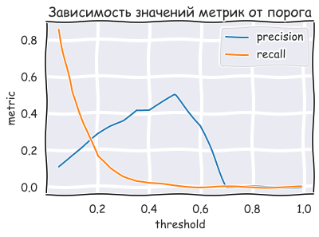

```python
estimator = grid_searcher.best_estimator_
estimator.fit(feats_train.values,labels_train.values)

prb = estimator.predict_proba(feats_val.values)

print(f'ROC AUC: {roc_auc_score(labels_val.values,prb[:,1])}')
print(f'PRC AUC: {average_precision_score(labels_val.values,prb[:,1])}')

pred = estimator.predict(feats_val.values)
print(classification_report(labels_val.values,pred))
print('------------------')
print('------------------')

pr_plot(labels_val.values,prb,[0.05,0.1,0.2,0.25,0.3,0.35,0.4,0.5,0.6,0.7,0.8,0.9,0.95,0.96,0.97,0.99])
```

```python
%%time
estimator.fit(features.values,labels.values)
probs = estimator.predict_proba(test_data.values)
write_to_submission_file(probs[:,1],out_file='submission8.csv')
```

```
Wall time: 1min 3s
```

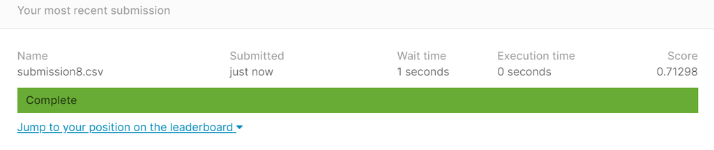

Результат можно было бы предугадать, если посмотреть на качество на отложенной выборке, при этом кросс-валидация дала неверный результат, хотя доверяться ей при таких небольших отличиях не стоит, с моей точки зрения. Изначальные параметры трансформера с прошлой недели лучше.

4. Также вы уже реализовали несколько стратегий для обработки категориальных признаков. Сравните эти стратегии между собой с помощью оценки качества моделей по кросс-валидации, построенных на датасетах с использованием различных стратегий. Как обработка категориальных признаков сказывается на качестве модели? Какой вариант выглядит наиболее оптимальным с точки зрения качества?

```python
%%time
for (low_cardinality_cat_transformer1,high_cardinality_cat_transformer1) in itertools.product([preprocessing.OneHotEncoder(handle_unknown = 'ignore'),\
                                                                              BinaryEncoder()],
                                                                              [preprocessing.OneHotEncoder(handle_unknown = 'ignore'),\
                                                                              BinaryEncoder(),\
                                                                              LeaveOneOutEncoder(),\
                                                                              TargetEncoder()]):

    low_level_transformers1 = [numeric_imputer,numeric_scaler,cat_imputer1,cat_imputer2,\
                low_cardinality_cat_transformer1,high_cardinality_cat_transformer1]

    transformer1 = transformation(low_level_transformers1,indices_lists)

    clf = xgb.XGBClassifier(random_state=42,n_estimators=100,gamma=0.1,max_depth=3,reg_alpha=1)

    estimator = Estimator(transformer1,clf)

    scores = cross_val_score(estimator,feats_train.values,labels_train.values,cv=skf,\
                             scoring='roc_auc',n_jobs=-1)
    score_mean = scores.mean()
    score_std = scores.std()

    print(f'transformers: {low_cardinality_cat_transformer1,high_cardinality_cat_transformer1}')
    print(f'score mean: {score_mean}, score std: {score_std}')
    print('------------')
    print('------------')
```

```
transformers: (OneHotEncoder(categories='auto', drop=None, dtype=<class 'numpy.float64'>,
              handle_unknown='ignore', sparse=True), OneHotEncoder(categories='auto', drop=None, dtype=<class 'numpy.float64'>,
              handle_unknown='ignore', sparse=True))
score mean: 0.744524146280961, score std: 0.010937380693947852
------------
------------
transformers: (OneHotEncoder(categories='auto', drop=None, dtype=<class 'numpy.float64'>,
              handle_unknown='ignore', sparse=True), BinaryEncoder(cols=None, drop_invariant=False, handle_missing='value',
              handle_unknown='value', mapping=None, return_df=True, verbose=0))
score mean: 0.7416260915625011, score std: 0.012396712745996276
------------
------------
transformers: (OneHotEncoder(categories='auto', drop=None, dtype=<class 'numpy.float64'>,
              handle_unknown='ignore', sparse=True), LeaveOneOutEncoder(cols=None, drop_invariant=False, handle_missing='value',
                   handle_unknown='value', random_state=None, return_df=True,
                   sigma=None, verbose=0))
score mean: 0.5678239578772672, score std: 0.00982963256947513
------------
------------
transformers: (OneHotEncoder(categories='auto', drop=None, dtype=<class 'numpy.float64'>,
              handle_unknown='ignore', sparse=True), TargetEncoder(cols=None, drop_invariant=False, handle_missing='value',
              handle_unknown='value', min_samples_leaf=1, return_df=True,
              smoothing=1.0, verbose=0))
score mean: 0.5685201315008103, score std: 0.010373175218661417
------------
------------
transformers: (BinaryEncoder(cols=None, drop_invariant=False, handle_missing='value',
              handle_unknown='value', mapping=None, return_df=True, verbose=0), OneHotEncoder(categories='auto', drop=None, dtype=<class 'numpy.float64'>,
              handle_unknown='ignore', sparse=True))
score mean: 0.7438489633108676, score std: 0.010822215709967806
------------
------------
transformers: (BinaryEncoder(cols=None, drop_invariant=False, handle_missing='value',
              handle_unknown='value', mapping=None, return_df=True, verbose=0), BinaryEncoder(cols=None, drop_invariant=False, handle_missing='value',
              handle_unknown='value', mapping=None, return_df=True, verbose=0))
score mean: 0.7398657284883754, score std: 0.014644235443174395
------------
------------
transformers: (BinaryEncoder(cols=None, drop_invariant=False, handle_missing='value',
              handle_unknown='value', mapping=None, return_df=True, verbose=0), LeaveOneOutEncoder(cols=None, drop_invariant=False, handle_missing='value',
                   handle_unknown='value', random_state=None, return_df=True,
                   sigma=None, verbose=0))
score mean: 0.5671614472544622, score std: 0.00947688902339638
------------
------------
transformers: (BinaryEncoder(cols=None, drop_invariant=False, handle_missing='value',
              handle_unknown='value', mapping=None, return_df=True, verbose=0), TargetEncoder(cols=None, drop_invariant=False, handle_missing='value',
              handle_unknown='value', min_samples_leaf=1, return_df=True,
              smoothing=1.0, verbose=0))
score mean: 0.5681203636008113, score std: 0.009694811672295196
------------
------------
Wall time: 19min 23s
```

```python
%%time
(low_cardinality_cat_transformer1,high_cardinality_cat_transformer1) = (preprocessing.OneHotEncoder(handle_unknown = 'ignore'),
                                                                        preprocessing.OneHotEncoder(handle_unknown = 'ignore'))


low_level_transformers1 = [numeric_imputer,numeric_scaler,cat_imputer1,cat_imputer2,\
                low_cardinality_cat_transformer1,high_cardinality_cat_transformer1]

transformer1 = transformation(low_level_transformers1,indices_lists)

clf = xgb.XGBClassifier(random_state=42,n_estimators=100,gamma=0.1,max_depth=3,reg_alpha=1)

estimator = Estimator(transformer1,clf)

estimator.fit(feats_train.values,labels_train.values)

prb = estimator.predict_proba(feats_val.values)

print(f'ROC AUC: {roc_auc_score(labels_val.values,prb[:,1])}')
print(f'PRC AUC: {average_precision_score(labels_val.values,prb[:,1])}')

pred = estimator.predict(feats_val.values)
print(classification_report(labels_val.values,pred))
print('------------------')
print('------------------')

pr_plot(labels_val.values,prb,[0.05,0.1,0.2,0.25,0.3,0.35,0.4,0.5,0.6,0.7,0.8,0.9,0.95,0.96,0.97,0.99])
```

[output not shown]

```
ROC AUC: 0.7378596430063221
PRC AUC: 0.2077076585475081
              precision    recall  f1-score   support

          -1       0.93      1.00      0.96     11107
           1       0.55      0.01      0.02       893

    accuracy                           0.93     12000
   macro avg       0.74      0.51      0.49     12000
weighted avg       0.90      0.93      0.89     12000

------------------
------------------
```

```
Wall time: 37.9 s
```

```python
%%time
estimator.fit(features.values,labels.values)
probs = estimator.predict_proba(test_data.values)
write_to_submission_file(probs[:,1],out_file='submission9.csv')
```

```
Wall time: 46 s
```

[figure not shown]

Итак, использование one_hot_encoder для всех категориальных признаков является наилучшим вариантом, хотя улучшение очень незначительно по сравнению с базой на этой неделе (там для категориальных признаков с большим количеством категорий использовалось бинарное кодирование).

5. Все ли признаки оказались полезными для построения моделей? Проведите процедуру отбора признаков, попробуйте разные варианты отбора (обратите внимание на модуль `sklearn.feature_selection`). Например, можно выбрасывать случайные признаки или строить отбор на основе l1-регуляризации - отфильтровать из обучения признаки, которые получат нулевой вес при построении регрессии с l1-регуляризацией (`sklearn.linear_model.Lasso`). И всегда можно придумать что-то своё=) Попробуйте как минимум 2 различные стратегии, сравните результаты. Помог ли отбор признаков улучшить качество модели? Поясните свой ответ.

В целом, вариантов моделей для отбора признаков в sklearn много, при этом те, где отбор ведется по порогу дисперсии, не подходят в связи с разным масштабом признаков и использованием индикаторных признаков, модели, основанные на отборе k лучших по степени взаимосвязи с откликом, отбрасываем, поскольку, на мой взгляд, трудно учесть все зависимости, а также нужна кросс-валидация для отбора k. Также есть вариант жадно удалять признаки и смотреть на ошибку, но при тысячах признаков решений будет очень долгим, при этом недостаток подхода в его жадности.

Остановимся на отборе на основе дополнительных классификаторов. Порядок таков: сначала трансформация исходного датасета в цифры, как и ранее, затем обучение на полученных данных выбранного дополнительного алгоритма, потом отбор на основе важности признаков (либо берется coef_, либо feature*importances*), и, наконец, применение основного алгоритма. Сначала попробуем линейные модели, затем ансамбли.

```python
class EstimatorSelectorFromModel(BaseEstimator, TransformerMixin):

    def __init__(self, transformer,selecting_estimator,classifier):
        self.transformer = transformer
        self.selecting_estimator = selecting_estimator
        self.classifier = classifier

    def fit(self, X, y):
        self.transformer.fit(X,y)
        X_tr = self.transformer.transform(X)

        self.selecting_estimator.fit(X_tr,y)
        self.selecting_model = SelectFromModel(self.selecting_estimator, prefit=True)
        X_new = self.selecting_model.transform(X_tr)

        self.classifier.fit(X_new,y)
        return self.classifier

    def predict(self, X):
        X_tr = self.transformer.transform(X)
        X_new = self.selecting_model.transform(X_tr)
        return self.classifier.predict(X_new)

    def predict_proba(self,X):
        X_tr = self.transformer.transform(X)
        X_new = self.selecting_model.transform(X_tr)
        return self.classifier.predict_proba(X_new)
```

```python
selecting_est = LinearSVC(C=0.01, penalty="l1", dual=False)
```

```
ROC AUC: 0.7324893021168112
PRC AUC: 0.202704421498826
              precision    recall  f1-score   support

          -1       0.93      1.00      0.96     11107
           1       0.47      0.01      0.02       893

    accuracy                           0.93     12000
   macro avg       0.70      0.50      0.49     12000
weighted avg       0.89      0.93      0.89     12000

------------------
------------------
```

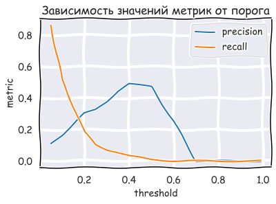

```python
warnings.filterwarnings('ignore')
clf = xgb.XGBClassifier(random_state=42,n_estimators=100,gamma=0.1,max_depth=3,reg_alpha=1)

estimator = EstimatorSelectorFromModel(transformer1,selecting_est,clf)

estimator.fit(feats_train.values,labels_train.values)

prb = estimator.predict_proba(feats_val.values)

print(f'ROC AUC: {roc_auc_score(labels_val.values,prb[:,1])}')
print(f'PRC AUC: {average_precision_score(labels_val.values,prb[:,1])}')

pred = estimator.predict(feats_val.values)
print(classification_report(labels_val.values,pred))
print('------------------')
print('------------------')

pr_plot(labels_val.values,prb,[0.05,0.1,0.2,0.25,0.3,0.35,0.4,0.5,0.6,0.7,0.8,0.9,0.95,0.96,0.97,0.99])
```

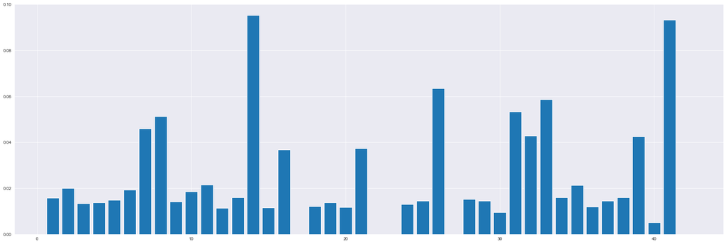

```python
plt.figure(figsize=(30,10))
importances = estimator.classifier.feature_importances_
plt.bar(range(1,importances.shape[0]+1),importances);
```

```
ROC AUC: 0.7352099616163692
PRC AUC: 0.203085763991453
              precision    recall  f1-score   support

          -1       0.93      1.00      0.96     11107
           1       0.41      0.01      0.02       893

    accuracy                           0.93     12000
   macro avg       0.67      0.50      0.49     12000
weighted avg       0.89      0.93      0.89     12000

------------------
------------------
```

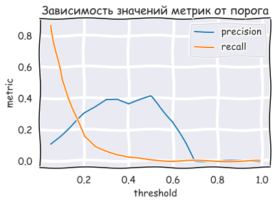

```python
warnings.filterwarnings('ignore')
selecting_est = LogisticRegression(C=0.5,penalty='l1',solver='liblinear')
clf = xgb.XGBClassifier(random_state=42,n_estimators=100,gamma=0.1,max_depth=3,reg_alpha=1)

estimator = EstimatorSelectorFromModel(transformer1,selecting_est,clf)

estimator.fit(feats_train.values,labels_train.values)

prb = estimator.predict_proba(feats_val.values)

print(f'ROC AUC: {roc_auc_score(labels_val.values,prb[:,1])}')
print(f'PRC AUC: {average_precision_score(labels_val.values,prb[:,1])}')

pred = estimator.predict(feats_val.values)
print(classification_report(labels_val.values,pred))
print('------------------')
print('------------------')

pr_plot(labels_val.values,prb,[0.05,0.1,0.2,0.25,0.3,0.35,0.4,0.5,0.6,0.7,0.8,0.9,0.95,0.96,0.97,0.99])
```

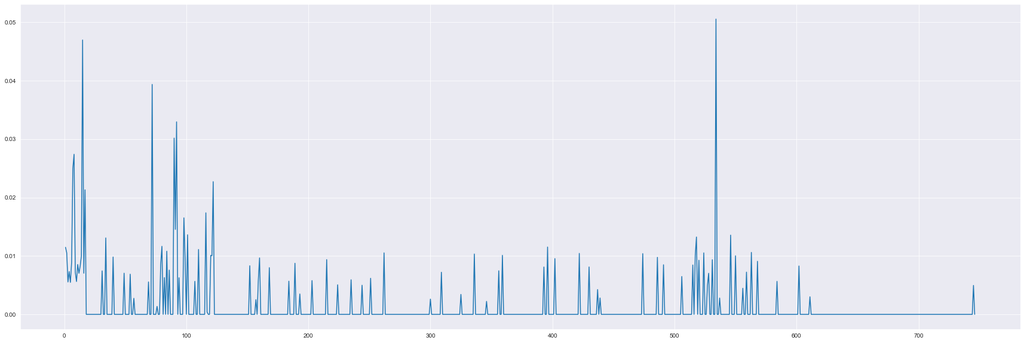

```python
plt.figure(figsize=(30,10))
importances = estimator.classifier.feature_importances_
plt.plot(range(1,importances.shape[0]+1),importances);
```

В целом, линейные модели с l1 регуляризацией ведут себя схожим оборазом. При этом, качество не растет. Можно подобрать параметр регуляризации на кросс-валидации, но, на мой взгляд, лучше использовать модели посложнее, чтобы не удалить признаки, которые характеризуют сложные зависимости между объектами и откликом.

Попробуем дважды применить наш лучший алгоритм, а после проверки такого отбора из любопытства посмотрим, как поведет себя случайный лес.

```python
warnings.filterwarnings('ignore')
selecting_est = xgb.XGBClassifier(random_state=42,n_estimators=100,gamma=0.1,max_depth=3,reg_alpha=1)
clf = xgb.XGBClassifier(random_state=42,n_estimators=100,gamma=0.1,max_depth=3,reg_alpha=1)

estimator = EstimatorSelectorFromModel(transformer1,selecting_est,clf)

estimator.fit(feats_train.values,labels_train.values)

prb = estimator.predict_proba(feats_val.values)

print(f'ROC AUC: {roc_auc_score(labels_val.values,prb[:,1])}')
print(f'PRC AUC: {average_precision_score(labels_val.values,prb[:,1])}')

pred = estimator.predict(feats_val.values)
print(classification_report(labels_val.values,pred))
print('------------------')
print('------------------')

pr_plot(labels_val.values,prb,[0.05,0.1,0.2,0.25,0.3,0.35,0.4,0.5,0.6,0.7,0.8,0.9,0.95,0.96,0.97,0.99])
```

[output not shown]

```
ROC AUC: 0.7378596430063221
PRC AUC: 0.2077076585475081
              precision    recall  f1-score   support

          -1       0.93      1.00      0.96     11107
           1       0.55      0.01      0.02       893

    accuracy                           0.93     12000
   macro avg       0.74      0.51      0.49     12000
weighted avg       0.90      0.93      0.89     12000

------------------
------------------
```

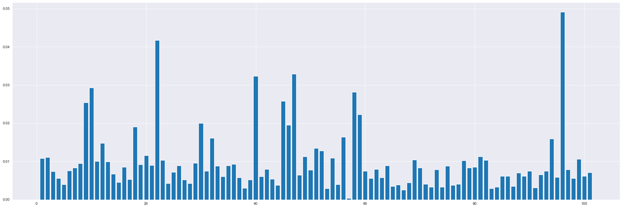

```python
plt.figure(figsize=(30,10))
importances = estimator.classifier.feature_importances_
plt.bar(range(1,importances.shape[0]+1),importances);
```

```
ROC AUC: 0.7378433603860081
PRC AUC: 0.20710677199619593
              precision    recall  f1-score   support

          -1       0.93      1.00      0.96     11107
           1       0.53      0.01      0.02       893

    accuracy                           0.93     12000
   macro avg       0.73      0.51      0.49     12000
weighted avg       0.90      0.93      0.89     12000

------------------
------------------
```

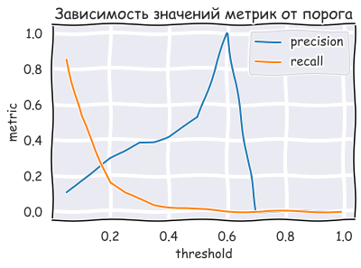

```python
warnings.filterwarnings('ignore')
selecting_est = RandomForestClassifier()
clf = xgb.XGBClassifier(random_state=42,n_estimators=100,gamma=0.1,max_depth=3,reg_alpha=1)

estimator = EstimatorSelectorFromModel(transformer1,selecting_est,clf)

estimator.fit(feats_train.values,labels_train.values)

prb = estimator.predict_proba(feats_val.values)

print(f'ROC AUC: {roc_auc_score(labels_val.values,prb[:,1])}')
print(f'PRC AUC: {average_precision_score(labels_val.values,prb[:,1])}')

pred = estimator.predict(feats_val.values)
print(classification_report(labels_val.values,pred))
print('------------------')
print('------------------')

pr_plot(labels_val.values,prb,[0.05,0.1,0.2,0.25,0.3,0.35,0.4,0.5,0.6,0.7,0.8,0.9,0.95,0.96,0.97,0.99])
```

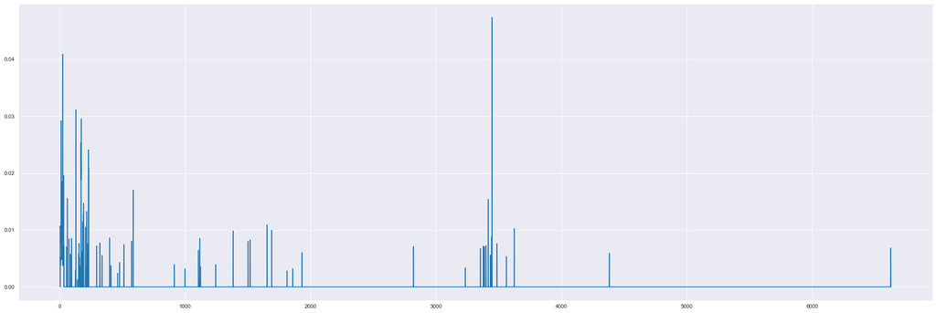

```python
plt.figure(figsize=(30,10))
importances = estimator.classifier.feature_importances_
plt.plot(range(1,importances.shape[0]+1),importances);
```

Итак, можно увидеть, что качество при использовании выбранных стратегий отбора признаков не возросло, при этом RandomForest не помог в отборе вообще, что связано, думаю, с OneHotEncoding. Почему так? В самом начале функция предобработки уже сделала свое дело, признаков гораздо меньше, чем в исходном датасете. Потом после OneHotEncoding получаются тысячи признаков, из которых не все важны, но даже неважные признаки не портят качество, что связано, думаю, с тем, что объектов, в соответствии с кривыми обучения, более чем достаточно. При этом, конечно, при дополнительном отборе признаков гасится скорость работы модели.

6. Подберите оптимальные параметры модели. Обратите внимание, что в зависимости от того, как вы обработали исходные данные, сделали ли балансировку классов, сколько объектов оставили в обучающей выборке и др. оптимальные значения параметров могут меняться. Возьмите наилучшее из ваших решений на текущий момент и проведите процедуру подбора параметров модели (обратите внимание на `sklearn.model_selection.GridSearchCV`) Как подбор параметров повлиял на качество модели?

Попробуем продублировать сделанные на прошлой неделе шаги, используя большее количество фолдов (было 3, стало 7).

```python
%%time
param_grid2= {'classifier__gamma':[0,0.01,0.1],
              'classifier__max_depth':[3,5,7],
              'classifier__reg_alpha':[0,0.5,1]
             }
clf = xgb.XGBClassifier(random_state=42,n_estimators=100,gamma=0.1,max_depth=3,reg_alpha=1)
estimator = Estimator(transformer1,clf)
grid_searcher = GridSearchCV(estimator,param_grid2,cv=skf,n_jobs=-1,scoring='roc_auc')
grid_searcher.fit(feats_train.values, labels_train.values)
print(f'best score: {grid_searcher.best_score_}')
print(f'best parameters: {grid_searcher.best_params_}')
```

```
best score: 0.744524146280961
best parameters: {'classifier__gamma': 0.1, 'classifier__max_depth': 3, 'classifier__reg_alpha': 1}
Wall time: 1h 6min 59s
```

```python
%%time
param_grid3= {'classifier__n_estimators':[50,100,120,150]
             }
clf = xgb.XGBClassifier(random_state=42,n_estimators=100,gamma=0.1,max_depth=3,reg_alpha=1)
estimator = Estimator(transformer1,clf)
grid_searcher = GridSearchCV(estimator,param_grid3,cv=skf,n_jobs=-1,scoring='roc_auc')
grid_searcher.fit(feats_train.values, labels_train.values)
print(f'best score: {grid_searcher.best_score_}')
print(f'best parameters: {grid_searcher.best_params_}')
```

```
best score: 0.744524146280961
best parameters: {'classifier__n_estimators': 100}
Wall time: 8min 9s
```

```python
%%time
param_grid4= {'classifier__gamma':[0.1,0.15,0.2,0.25,0.3],
             }
clf = xgb.XGBClassifier(random_state=42,n_estimators=100,gamma=0.1,max_depth=3,reg_alpha=1)
estimator = Estimator(transformer1,clf)
grid_searcher = GridSearchCV(estimator,param_grid4,cv=skf,n_jobs=-1,scoring='roc_auc')
grid_searcher.fit(feats_train.values, labels_train.values)
print(f'best score: {grid_searcher.best_score_}')
print(f'best parameters: {grid_searcher.best_params_}')
```

```
best score: 0.744524146280961
best parameters: {'classifier__gamma': 0.1}
Wall time: 10min 23s
```

```python
%%time
param_grid4= {'classifier__subsample':[0.5,0.8,1],
              'classifier__colsample_bytree':[0.5,0.8,1],
              'classifier__min_child_weight':[1,3,5]
             }
clf = xgb.XGBClassifier(random_state=42,n_estimators=100,gamma=0.1,max_depth=3,reg_alpha=1)
estimator = Estimator(transformer1,clf)
grid_searcher = GridSearchCV(estimator,param_grid4,cv=skf,n_jobs=-1,scoring='roc_auc')
grid_searcher.fit(feats_train.values, labels_train.values)
print(f'best score: {grid_searcher.best_score_}')
print(f'best parameters: {grid_searcher.best_params_}')
```

```
best score: 0.744524146280961
best parameters: {'classifier__colsample_bytree': 1, 'classifier__min_child_weight': 1, 'classifier__subsample': 1}
Wall time: 40min 22s
```

```python
%%time
param_grid5= {'classifier__learning_rate':[0.01,0.02,0.05,0.08,0.1]
             }
clf = xgb.XGBClassifier(random_state=42,n_estimators=100,gamma=0.1,max_depth=3,reg_alpha=1,min_child_weight=1)
estimator = Estimator(transformer1,clf)
grid_searcher = GridSearchCV(estimator,param_grid5,cv=skf,n_jobs=-1,scoring='roc_auc')
grid_searcher.fit(feats_train.values, labels_train.values)
print(f'best score: {grid_searcher.best_score_}')
print(f'best parameters: {grid_searcher.best_params_}')
```

```
best score: 0.744524146280961
best parameters: {'classifier__learning_rate': 0.1}
Wall time: 9min 6s
```

```python
%%time
param_grid6= {'classifier__booster':['gbtree','dart']
             }
clf = xgb.XGBClassifier(random_state=42,n_estimators=100,gamma=0.1,max_depth=3,reg_alpha=1,min_child_weight=1)
estimator = Estimator(transformer1,clf)
grid_searcher = GridSearchCV(estimator,param_grid6,cv=skf,n_jobs=-1,scoring='roc_auc')
grid_searcher.fit(feats_train.values, labels_train.values)
print(f'best score: {grid_searcher.best_score_}')
print(f'best parameters: {grid_searcher.best_params_}')
```

```
best score: 0.744524146280961
best parameters: {'classifier__booster': 'gbtree'}
Wall time: 4min 32s
```

```python
%%time
param_grid6= {'classifier__booster':['gbtree','dart']
             }
clf = xgb.XGBClassifier(random_state=42)
estimator = Estimator(transformer1,clf)
grid_searcher = GridSearchCV(estimator,param_grid6,cv=skf,n_jobs=-1,scoring='roc_auc')
grid_searcher.fit(feats_train.values, labels_train.values)
print(f'best score: {grid_searcher.best_score_}')
print(f'best parameters: {grid_searcher.best_params_}')
```

```
best score: 0.743338324639941
best parameters: {'classifier__booster': 'gbtree'}
Wall time: 6min 43s
```

```python
clf = xgb.XGBClassifier(random_state=42,n_estimators=100,gamma=0.1,max_depth=3,reg_alpha=1,min_child_weight=1)

estimator = Estimator(transformer1,clf)

estimator.fit(feats_train.values,labels_train.values)

prb = estimator.predict_proba(feats_val.values)

print(f'ROC AUC: {roc_auc_score(labels_val.values,prb[:,1])}')
print(f'PRC AUC: {average_precision_score(labels_val.values,prb[:,1])}')

pred = estimator.predict(feats_val.values)
print(classification_report(labels_val.values,pred))
print('------------------')
print('------------------')

pr_plot(labels_val.values,prb,[0.05,0.1,0.2,0.25,0.3,0.35,0.4,0.5,0.6,0.7,0.8,0.9,0.95,0.96,0.97,0.99])
```

[output not shown]

```
ROC AUC: 0.7378596430063221
PRC AUC: 0.2077076585475081
              precision    recall  f1-score   support

          -1       0.93      1.00      0.96     11107
           1       0.55      0.01      0.02       893

    accuracy                           0.93     12000
   macro avg       0.74      0.51      0.49     12000
weighted avg       0.90      0.93      0.89     12000

------------------
------------------
```

Итак, шаги привели нас к той же модели, единственное изменение - минимальное количество наблюдений в листе стало 1, но качество не возрасло. Это показывает тот факт, что при такой малой глубине деревьев совершенно не важно, какой минимальный состав листа мы укажем, до него все равно не дойдет. Но вот большие значения стоило бы попробовать.

7. Предложите методику оценки того, какие признаки внесли наибольший вклад в модель (например, это могут быть веса в случае регрессии, а также большое количество моделей реализуют метод `feature_importances_` - оценка важности признаков). На основе предложенной методики проанализируйте, какие признаки внесли больший вклад в модель, а какие меньший?

Посмотрим на диаграмму степени важности признаков по результатам работы выбранного алгоритма.

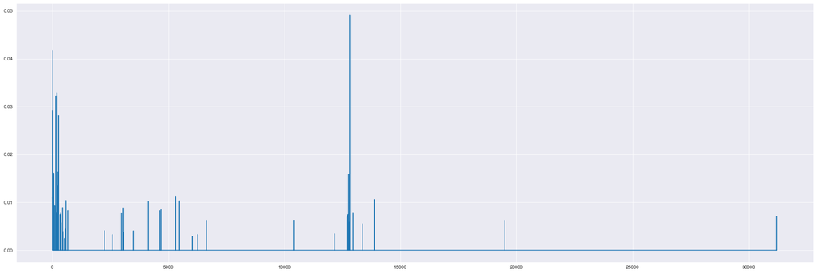

```python
plt.figure(figsize=(30,10))
plt.plot(estimator.classifier.feature_importances_);
```

Числовые данные после препроцессинга, проведенного еще на прошлой неделе

```python
feats_train[feats_train.columns[indices_lists[0]]].head()
```

|  | Var6 | Var13 | Var21 | Var22 | Var24 | Var25 | Var28 | Var38 | Var57 | Var73 | ... | Var125 | Var126 | Var133 | Var134 | Var140 | Var149 | Var153 | Var160 | Var163 | Var189 |
| --- | --- | --- | --- | --- | --- | --- | --- | --- | --- | --- | --- | --- | --- | --- | --- | --- | --- | --- | --- | --- | --- |
| 6892 | NaN | NaN | NaN | NaN | NaN | NaN | NaN | NaN | 0.657125 | 8 | ... | NaN | -18.0 | NaN | NaN | NaN | NaN | NaN | NaN | NaN | NaN |
| 34821 | NaN | NaN | NaN | NaN | NaN | NaN | NaN | NaN | 0.117069 | 10 | ... | NaN | 4.0 | NaN | NaN | NaN | NaN | NaN | NaN | NaN | NaN |
| 34190 | 98.0 | 0.0 | 152.0 | 190.0 | 0.0 | 64.0 | 86.96 | 4107204.0 | 2.271523 | 14 | ... | 0.0 | -26.0 | 1585040.0 | 728196.0 | 0.0 | 0.0 | 8437160.0 | 16.0 | 1426026.0 | NaN |
| 24541 | 938.0 | 520.0 | 148.0 | 185.0 | 2.0 | 96.0 | 186.64 | 749586.0 | 0.714591 | 160 | ... | 68571.0 | NaN | 3873950.0 | 2044820.0 | 4160.0 | 604800.0 | 10517440.0 | 20.0 | 2592000.0 | NaN |
| 31483 | 602.0 | 88.0 | 0.0 | 0.0 | NaN | 0.0 | 166.56 | 0.0 | 3.250160 | 30 | ... | 9657.0 | 4.0 | 0.0 | 0.0 | 385.0 | NaN | 0.0 | 0.0 | 0.0 | NaN |

5 rows × 31 columns

Категориальные данные

```python
feats_train[feats_train.columns[indices_lists[1]]].head()
```

|  | Var7 | Var35 | Var44 | Var65 | Var72 | Var78 | Var132 | Var143 | Var144 | Var173 | ... | Var210 | Var211 | Var218 | Var219 | Var221 | Var223 | Var225 | Var226 | Var227 | Var229 |
| --- | --- | --- | --- | --- | --- | --- | --- | --- | --- | --- | --- | --- | --- | --- | --- | --- | --- | --- | --- | --- | --- |
| 6892 | NaN | NaN | NaN | NaN | NaN | NaN | NaN | NaN | NaN | NaN | ... | uKAI | Mtgm | cJvF | AU8pNoi | oslk | LM8l689qOp | NaN | Qu4f | RAYp | NaN |
| 34821 | NaN | NaN | NaN | NaN | NaN | NaN | NaN | NaN | NaN | NaN | ... | uKAI | L84s | cJvF | NaN | oslk | NaN | NaN | w_Ub | RAYp | NaN |
| 34190 | 0.0 | 5.0 | 0.0 | 18.0 | 6.0 | 0.0 | 8.0 | 0.0 | 0.0 | 0.0 | ... | uKAI | L84s | cJvF | FzaX | oslk | LM8l689qOp | NaN | Qu4f | RAYp | NaN |
| 24541 | 7.0 | 0.0 | 0.0 | 18.0 | 6.0 | 0.0 | 0.0 | 0.0 | 18.0 | 0.0 | ... | uKAI | L84s | cJvF | FzaX | zCkv | jySVZNlOJy | ELof | WqMG | ZI9m | mj86 |
| 31483 | 7.0 | 0.0 | 0.0 | 9.0 | 3.0 | 0.0 | 0.0 | 0.0 | 0.0 | 0.0 | ... | uKAI | L84s | cJvF | FzaX | oslk | LM8l689qOp | NaN | FSa2 | RAYp | NaN |

5 rows × 28 columns

```python
feats_train[feats_train.columns[indices_lists[2]]].head()
```

|  | Var192 | Var193 | Var197 | Var198 | Var199 | Var202 | Var204 | Var212 | Var216 | Var217 | Var220 | Var222 | Var228 |
| --- | --- | --- | --- | --- | --- | --- | --- | --- | --- | --- | --- | --- | --- |
| 6892 | DHeTmBftjz | RO12 | 7gSz | 8ij6Lg8 | LJF4fPp | Bcur | Z5OU | NhsEn4L | 7WwCtIM | 1GbF | 7OmVzos | 76DJixu | F2FyR07IdsN7I |
| 34821 | 2jigUH7ejg | RO12 | dm89 | LG0vbUP | n1zVHpT8NN | 5FzM | DmlN | NhsEn4L | mAja5EA | FJ56cYO | sE0uLpj | G9maF5M | F2FyR07IdsN7I |
| 34190 | zcRZptzip9 | RO12 | USOt | pro8v8X | CsjH_hi | rUBc | t_4G | NhsEn4L | mAjDcoz | xYrN | meWVy8V | DQ3u3MC | F2FyR07IdsN7I |
| 24541 | mzKvyx8zhV | 2Knk1KF | vSNn | fhk21Ss | Hz673939hSRjL | W9XQ | QMes | Ie_5MZs | XTbjhEX | F6F0 | 4UxGlow | catzS2D | TCU50_Yjmm6GIBZ0lL_ |
| 31483 | 639qrQK2Mx | RO12 | AHgj | creg0bq | 5q1hF23 | 6Yf9 | 15m3 | NhsEn4L | mAjbk_S | oLcf | VgKv48t | nRgz4Af | F2FyR07IdsN7I |

Видно, что конкректно уловить, какие признаки по номерам наиболее харектеризуют классы, сложно, поскольку мы смотрим на картину после OneHotEncoding. При этом, можно проследить общую закономерность, что большинство числовых признаков значимые, а большинство индикаторных признаков незначимы. Нужно также учитывать, что некоторые индикаторные признаки чрезвычайно значимы, даже больше числовых, что говорит о недопустимости удаления категориальных признаков из рассмотрения.

8. Напоследок давайте посмотрим на объекты. На каких объектах достигается наибольшая ошибка классификации? Есть ли межу этими объектами что-то общее? Видны ли какие-либо закономерности? Предположите, почему наибольшая ошибка достигается именно на этих объектах. В данном случае "наибольшую" ошибку можно понимать как отнесение объекта с чужому классу с большой долей уверенности (с высокой вероятностью).

Получим решение и применим его к валидационной выборке. Далее вычленим по 5 наиболее ошибочно классифицированных объектов каждого класса.

```python
warnings.filterwarnings('ignore')
clf = xgb.XGBClassifier(random_state=42,n_estimators=100,gamma=0.1,max_depth=3,reg_alpha=1,min_child_weight=1)

estimator = Estimator(transformer1,clf)

estimator.fit(feats_train.values,labels_train.values)

prb = estimator.predict_proba(feats_val.values)

print(f'ROC AUC: {roc_auc_score(labels_val.values,prb[:,1])}')
print(f'PRC AUC: {average_precision_score(labels_val.values,prb[:,1])}')

pred = estimator.predict(feats_val.values)
print(classification_report(labels_val.values,pred))
print('------------------')
print('------------------')

pr_plot(labels_val.values,prb,[0.05,0.1,0.2,0.25,0.3,0.35,0.4,0.5,0.6,0.7,0.8,0.9,0.95,0.96,0.97,0.99])
```

[output not shown]

```
ROC AUC: 0.7378596430063221
PRC AUC: 0.2077076585475081
              precision    recall  f1-score   support

          -1       0.93      1.00      0.96     11107
           1       0.55      0.01      0.02       893

    accuracy                           0.93     12000
   macro avg       0.74      0.51      0.49     12000
weighted avg       0.90      0.93      0.89     12000

------------------
------------------
```

```python
important_columns = feats_train.columns[indices_lists[0]+indices_lists[1]+indices_lists[2]]
important_columns.shape
```

```
(72,)
```

```python
feats_important_val = feats_val.copy()[important_columns]
feats_important_val.head()
```

|  | Var6 | Var7 | Var13 | Var21 | Var22 | Var24 | Var25 | Var28 | Var35 | Var38 | ... | Var219 | Var220 | Var221 | Var222 | Var223 | Var225 | Var226 | Var227 | Var228 | Var229 |
| --- | --- | --- | --- | --- | --- | --- | --- | --- | --- | --- | --- | --- | --- | --- | --- | --- | --- | --- | --- | --- | --- |
| 16632 | 868.0 | 7.0 | 440.0 | 136.0 | 170.0 | 0.0 | 8.0 | 186.64 | 0.0 | 9113040.0 | ... | FzaX | wIfAM23 | oslk | dwbKSUK | jySVZNlOJy | NaN | 7P5s | RAYp | F2FyR07IdsN7I | NaN |
| 19989 | 518.0 | 7.0 | 1608.0 | 108.0 | 135.0 | 2.0 | 8.0 | 166.56 | 0.0 | 0.0 | ... | FzaX | UF16siJ | zCkv | APgdzOv | LM8l689qOp | kG3k | WqMG | 6fzt | 6nxx00q6gnIF8ePJ3P3AEfZ1N | NaN |
| 29828 | NaN | 0.0 | 0.0 | NaN | 40.0 | 0.0 | 8.0 | 43.92 | 0.0 | 650946.0 | ... | FzaX | q3qDGHt | oslk | USApVh5 | LM8l689qOp | NaN | WqMG | RAYp | F2FyR07IdsN7I | NaN |
| 799 | 1351.0 | 7.0 | 184.0 | 188.0 | 235.0 | 0.0 | 136.0 | 286.96 | 5.0 | 1168368.0 | ... | FzaX | BV9YlW4 | oslk | 2fF2Oqu | jySVZNlOJy | NaN | FSa2 | RAYp | F2FyR07IdsN7I | NaN |
| 19881 | 154.0 | 0.0 | 0.0 | 80.0 | 100.0 | 0.0 | 24.0 | 186.64 | 5.0 | 1425678.0 | ... | FzaX | gfM8XLE | oslk | knDz20V | LM8l689qOp | NaN | kwS7 | RAYp | F2FyR07IdsN7I | NaN |

5 rows × 72 columns

```python
data_important_val= pd.concat([feats_important_val,labels_val],axis=1)
data_important_val.head()
```

|  | Var6 | Var7 | Var13 | Var21 | Var22 | Var24 | Var25 | Var28 | Var35 | Var38 | ... | Var220 | Var221 | Var222 | Var223 | Var225 | Var226 | Var227 | Var228 | Var229 | target |
| --- | --- | --- | --- | --- | --- | --- | --- | --- | --- | --- | --- | --- | --- | --- | --- | --- | --- | --- | --- | --- | --- |
| 16632 | 868.0 | 7.0 | 440.0 | 136.0 | 170.0 | 0.0 | 8.0 | 186.64 | 0.0 | 9113040.0 | ... | wIfAM23 | oslk | dwbKSUK | jySVZNlOJy | NaN | 7P5s | RAYp | F2FyR07IdsN7I | NaN | -1 |
| 19989 | 518.0 | 7.0 | 1608.0 | 108.0 | 135.0 | 2.0 | 8.0 | 166.56 | 0.0 | 0.0 | ... | UF16siJ | zCkv | APgdzOv | LM8l689qOp | kG3k | WqMG | 6fzt | 6nxx00q6gnIF8ePJ3P3AEfZ1N | NaN | -1 |
| 29828 | NaN | 0.0 | 0.0 | NaN | 40.0 | 0.0 | 8.0 | 43.92 | 0.0 | 650946.0 | ... | q3qDGHt | oslk | USApVh5 | LM8l689qOp | NaN | WqMG | RAYp | F2FyR07IdsN7I | NaN | -1 |
| 799 | 1351.0 | 7.0 | 184.0 | 188.0 | 235.0 | 0.0 | 136.0 | 286.96 | 5.0 | 1168368.0 | ... | BV9YlW4 | oslk | 2fF2Oqu | jySVZNlOJy | NaN | FSa2 | RAYp | F2FyR07IdsN7I | NaN | -1 |
| 19881 | 154.0 | 0.0 | 0.0 | 80.0 | 100.0 | 0.0 | 24.0 | 186.64 | 5.0 | 1425678.0 | ... | gfM8XLE | oslk | knDz20V | LM8l689qOp | NaN | kwS7 | RAYp | F2FyR07IdsN7I | NaN | 1 |

5 rows × 73 columns

```python
data_important_val['predicted_proba_to_pos'] = prb[:,1]
data_important_val['predicted_proba_to_pos'].head()
```

```
16632    0.075810
19989    0.117217
29828    0.108185
799      0.037752
19881    0.118872
Name: predicted_proba_to_pos, dtype: float32
```

```python
data_important_val_pos = data_important_val[data_important_val.target == 1].copy()
data_important_val_pos.head()
```

|  | Var6 | Var7 | Var13 | Var21 | Var22 | Var24 | Var25 | Var28 | Var35 | Var38 | ... | Var221 | Var222 | Var223 | Var225 | Var226 | Var227 | Var228 | Var229 | target | predicted_proba_to_pos |
| --- | --- | --- | --- | --- | --- | --- | --- | --- | --- | --- | --- | --- | --- | --- | --- | --- | --- | --- | --- | --- | --- |
| 19881 | 154.0 | 0.0 | 0.0 | 80.0 | 100.0 | 0.0 | 24.0 | 186.64 | 5.0 | 1425678.0 | ... | oslk | knDz20V | LM8l689qOp | NaN | kwS7 | RAYp | F2FyR07IdsN7I | NaN | 1 | 0.118872 |
| 717 | 322.0 | 7.0 | 228.0 | 84.0 | 105.0 | 2.0 | 64.0 | 220.08 | 0.0 | 0.0 | ... | oslk | 9BAMCCr | LM8l689qOp | NaN | 5Acm | RAYp | F2FyR07IdsN7I | NaN | 1 | 0.060222 |
| 34072 | 3990.0 | 7.0 | 3456.0 | 124.0 | 155.0 | 0.0 | 24.0 | 220.08 | 0.0 | 0.0 | ... | oslk | OskskzO | LM8l689qOp | ELof | 453m | RAYp | 55YFVY9 | mj86 | 1 | 0.068604 |
| 37820 | 686.0 | 7.0 | 8.0 | 80.0 | 100.0 | 2.0 | 16.0 | 166.56 | 0.0 | 21900.0 | ... | oslk | catzS2D | LM8l689qOp | xG3x | Qu4f | ZI9m | ib5G6X1eUxUn6 | mj86 | 1 | 0.053950 |
| 9618 | NaN | NaN | NaN | NaN | NaN | NaN | NaN | NaN | NaN | NaN | ... | oslk | ZwrmOr3 | LM8l689qOp | NaN | szEZ | RAYp | F2FyR07IdsN7I | NaN | 1 | 0.044990 |

5 rows × 74 columns

```python
pos_error_obj = data_important_val_pos[data_important_val_pos.predicted_proba_to_pos < 1.7e-2].copy()
pos_error_obj
```

|  | Var6 | Var7 | Var13 | Var21 | Var22 | Var24 | Var25 | Var28 | Var35 | Var38 | ... | Var221 | Var222 | Var223 | Var225 | Var226 | Var227 | Var228 | Var229 | target | predicted_proba_to_pos |
| --- | --- | --- | --- | --- | --- | --- | --- | --- | --- | --- | --- | --- | --- | --- | --- | --- | --- | --- | --- | --- | --- |
| 4309 | 1246.0 | 7.0 | 4712.0 | 180.0 | 225.0 | 4.0 | 128.0 | 176.56 | 0.0 | 3762.0 | ... | zCkv | catzS2D | LM8l689qOp | ELof | Xa3G | ZI9m | TCU50_Yjmm6GIBZ0lL_ | am7c | 1 | 0.006545 |
| 16147 | 1134.0 | 14.0 | 732.0 | 208.0 | 260.0 | 10.0 | 56.0 | 133.76 | 0.0 | 42048.0 | ... | oslk | KukjELi | LM8l689qOp | ELof | Qcbd | RAYp | F2FyR07IdsN7I | NaN | 1 | 0.012324 |
| 24260 | 4039.0 | 0.0 | 0.0 | 648.0 | 810.0 | 20.0 | 360.0 | 220.08 | 0.0 | 54858.0 | ... | oslk | IIvC99a | LM8l689qOp | kG3k | PM2D | RAYp | F2FyR07IdsN7I | mj86 | 1 | 0.015558 |
| 4012 | 2226.0 | 7.0 | 3908.0 | 504.0 | 630.0 | 14.0 | 296.0 | 223.36 | 0.0 | 369966.0 | ... | zCkv | catzS2D | LM8l689qOp | kG3k | FSa2 | ZI9m | ib5G6X1eUxUn6 | mj86 | 1 | 0.011051 |
| 36239 | 1645.0 | 7.0 | 2372.0 | 140.0 | 175.0 | 4.0 | 120.0 | 133.12 | 0.0 | 240.0 | ... | oslk | catzS2D | LM8l689qOp | kG3k | FSa2 | ZI9m | iyHGyLCEkQ | am7c | 1 | 0.016313 |

5 rows × 74 columns

```python
data_important_val_neg = data_important_val[data_important_val.target == -1].copy()
data_important_val_neg.head()
```

|  | Var6 | Var7 | Var13 | Var21 | Var22 | Var24 | Var25 | Var28 | Var35 | Var38 | ... | Var221 | Var222 | Var223 | Var225 | Var226 | Var227 | Var228 | Var229 | target | predicted_proba_to_pos |
| --- | --- | --- | --- | --- | --- | --- | --- | --- | --- | --- | --- | --- | --- | --- | --- | --- | --- | --- | --- | --- | --- |
| 16632 | 868.0 | 7.0 | 440.0 | 136.0 | 170.0 | 0.0 | 8.0 | 186.64 | 0.0 | 9113040.0 | ... | oslk | dwbKSUK | jySVZNlOJy | NaN | 7P5s | RAYp | F2FyR07IdsN7I | NaN | -1 | 0.075810 |
| 19989 | 518.0 | 7.0 | 1608.0 | 108.0 | 135.0 | 2.0 | 8.0 | 166.56 | 0.0 | 0.0 | ... | zCkv | APgdzOv | LM8l689qOp | kG3k | WqMG | 6fzt | 6nxx00q6gnIF8ePJ3P3AEfZ1N | NaN | -1 | 0.117217 |
| 29828 | NaN | 0.0 | 0.0 | NaN | 40.0 | 0.0 | 8.0 | 43.92 | 0.0 | 650946.0 | ... | oslk | USApVh5 | LM8l689qOp | NaN | WqMG | RAYp | F2FyR07IdsN7I | NaN | -1 | 0.108185 |
| 799 | 1351.0 | 7.0 | 184.0 | 188.0 | 235.0 | 0.0 | 136.0 | 286.96 | 5.0 | 1168368.0 | ... | oslk | 2fF2Oqu | jySVZNlOJy | NaN | FSa2 | RAYp | F2FyR07IdsN7I | NaN | -1 | 0.037752 |
| 36002 | NaN | NaN | NaN | NaN | NaN | NaN | NaN | NaN | NaN | NaN | ... | oslk | KBgRDbC | LM8l689qOp | NaN | 7aLG | RAYp | F2FyR07IdsN7I | NaN | -1 | 0.017493 |

5 rows × 74 columns

```python
max_prob=data_important_val_neg.predicted_proba_to_pos.max()
neg_error_obj = data_important_val_neg[data_important_val_neg.predicted_proba_to_pos > (max_prob - 8e-2)].copy()
neg_error_obj
```

|  | Var6 | Var7 | Var13 | Var21 | Var22 | Var24 | Var25 | Var28 | Var35 | Var38 | ... | Var221 | Var222 | Var223 | Var225 | Var226 | Var227 | Var228 | Var229 | target | predicted_proba_to_pos |
| --- | --- | --- | --- | --- | --- | --- | --- | --- | --- | --- | --- | --- | --- | --- | --- | --- | --- | --- | --- | --- | --- |
| 7029 | 147.0 | 0.0 | 0.0 | 64.0 | 80.0 | 0.0 | 16.0 | 132.00 | 0.0 | 338472.0 | ... | oslk | 00ARusu | NaN | NaN | WqMG | RAYp | F2FyR07IdsN7I | NaN | -1 | 0.578566 |
| 37867 | 28.0 | 0.0 | 0.0 | 28.0 | 35.0 | 0.0 | 8.0 | 253.52 | 10.0 | 0.0 | ... | oslk | R2LdzOv | LM8l689qOp | NaN | FSa2 | RAYp | F2FyR07IdsN7I | NaN | -1 | 0.537425 |
| 23720 | 14.0 | 0.0 | 0.0 | 40.0 | 50.0 | 0.0 | 64.0 | 20.08 | 0.0 | 35586.0 | ... | z4pH | _cPDUcR | LM8l689qOp | NaN | Qu4f | 02N6s8f | F2FyR07IdsN7I | NaN | -1 | 0.537234 |
| 9118 | 175.0 | 0.0 | 0.0 | 152.0 | 190.0 | 6.0 | 48.0 | 270.64 | 0.0 | 2495736.0 | ... | oslk | QkgQQMs | LM8l689qOp | NaN | 453m | RAYp | F2FyR07IdsN7I | NaN | -1 | 0.614242 |
| 21894 | 161.0 | 0.0 | 0.0 | 160.0 | 200.0 | 16.0 | 96.0 | 186.64 | 0.0 | 0.0 | ... | oslk | MI8s5nE | LM8l689qOp | NaN | Qcbd | RAYp | F2FyR07IdsN7I | NaN | -1 | 0.553530 |

5 rows × 74 columns

```python
pos_error_obj
```

|  | Var6 | Var7 | Var13 | Var21 | Var22 | Var24 | Var25 | Var28 | Var35 | Var38 | ... | Var221 | Var222 | Var223 | Var225 | Var226 | Var227 | Var228 | Var229 | target | predicted_proba_to_pos |
| --- | --- | --- | --- | --- | --- | --- | --- | --- | --- | --- | --- | --- | --- | --- | --- | --- | --- | --- | --- | --- | --- |
| 4309 | 1246.0 | 7.0 | 4712.0 | 180.0 | 225.0 | 4.0 | 128.0 | 176.56 | 0.0 | 3762.0 | ... | zCkv | catzS2D | LM8l689qOp | ELof | Xa3G | ZI9m | TCU50_Yjmm6GIBZ0lL_ | am7c | 1 | 0.006545 |
| 16147 | 1134.0 | 14.0 | 732.0 | 208.0 | 260.0 | 10.0 | 56.0 | 133.76 | 0.0 | 42048.0 | ... | oslk | KukjELi | LM8l689qOp | ELof | Qcbd | RAYp | F2FyR07IdsN7I | NaN | 1 | 0.012324 |
| 24260 | 4039.0 | 0.0 | 0.0 | 648.0 | 810.0 | 20.0 | 360.0 | 220.08 | 0.0 | 54858.0 | ... | oslk | IIvC99a | LM8l689qOp | kG3k | PM2D | RAYp | F2FyR07IdsN7I | mj86 | 1 | 0.015558 |
| 4012 | 2226.0 | 7.0 | 3908.0 | 504.0 | 630.0 | 14.0 | 296.0 | 223.36 | 0.0 | 369966.0 | ... | zCkv | catzS2D | LM8l689qOp | kG3k | FSa2 | ZI9m | ib5G6X1eUxUn6 | mj86 | 1 | 0.011051 |
| 36239 | 1645.0 | 7.0 | 2372.0 | 140.0 | 175.0 | 4.0 | 120.0 | 133.12 | 0.0 | 240.0 | ... | oslk | catzS2D | LM8l689qOp | kG3k | FSa2 | ZI9m | iyHGyLCEkQ | am7c | 1 | 0.016313 |

5 rows × 74 columns

```python
pos_error_obj.iloc[:,:20]
```

|  | Var6 | Var7 | Var13 | Var21 | Var22 | Var24 | Var25 | Var28 | Var35 | Var38 | Var44 | Var57 | Var65 | Var72 | Var73 | Var74 | Var76 | Var78 | Var81 | Var83 |
| --- | --- | --- | --- | --- | --- | --- | --- | --- | --- | --- | --- | --- | --- | --- | --- | --- | --- | --- | --- | --- |
| 4309 | 1246.0 | 7.0 | 4712.0 | 180.0 | 225.0 | 4.0 | 128.0 | 176.56 | 0.0 | 3762.0 | 0.0 | 2.390088 | 9.0 | NaN | 164 | 175.0 | 1531200.0 | 0.0 | 20317.980 | 0.0 |
| 16147 | 1134.0 | 14.0 | 732.0 | 208.0 | 260.0 | 10.0 | 56.0 | 133.76 | 0.0 | 42048.0 | 0.0 | 4.559495 | 18.0 | 6.0 | 76 | 105.0 | 139704.0 | 0.0 | 4446.630 | 10.0 |
| 24260 | 4039.0 | 0.0 | 0.0 | 648.0 | 810.0 | 20.0 | 360.0 | 220.08 | 0.0 | 54858.0 | 0.0 | 3.826746 | 9.0 | NaN | 64 | 0.0 | 620744.0 | 0.0 | 6418.650 | 0.0 |
| 4012 | 2226.0 | 7.0 | 3908.0 | 504.0 | 630.0 | 14.0 | 296.0 | 223.36 | 0.0 | 369966.0 | 0.0 | 1.620380 | 18.0 | 3.0 | 150 | 644.0 | 1544288.0 | 0.0 | 18130.950 | 10.0 |
| 36239 | 1645.0 | 7.0 | 2372.0 | 140.0 | 175.0 | 4.0 | 120.0 | 133.12 | 0.0 | 240.0 | 0.0 | 3.977996 | 18.0 | NaN | 174 | 42.0 | 22912.0 | 0.0 | 1934.283 | 0.0 |

```python
neg_error_obj.iloc[:,:20]
```

|  | Var6 | Var7 | Var13 | Var21 | Var22 | Var24 | Var25 | Var28 | Var35 | Var38 | Var44 | Var57 | Var65 | Var72 | Var73 | Var74 | Var76 | Var78 | Var81 | Var83 |
| --- | --- | --- | --- | --- | --- | --- | --- | --- | --- | --- | --- | --- | --- | --- | --- | --- | --- | --- | --- | --- |
| 7029 | 147.0 | 0.0 | 0.0 | 64.0 | 80.0 | 0.0 | 16.0 | 132.00 | 0.0 | 338472.0 | 0.0 | 1.578509 | 9.0 | NaN | 16 | 0.0 | 1267288.0 | 12.0 | 268313.40 | 5.0 |
| 37867 | 28.0 | 0.0 | 0.0 | 28.0 | 35.0 | 0.0 | 8.0 | 253.52 | 10.0 | 0.0 | 0.0 | 1.722495 | 9.0 | 3.0 | 16 | 0.0 | 0.0 | 0.0 | 1221846.00 | 15.0 |
| 23720 | 14.0 | 0.0 | 0.0 | 40.0 | 50.0 | 0.0 | 64.0 | 20.08 | 0.0 | 35586.0 | 0.0 | 0.535783 | 9.0 | NaN | 16 | 0.0 | 1455072.0 | 0.0 | 734622.00 | 0.0 |
| 9118 | 175.0 | 0.0 | 0.0 | 152.0 | 190.0 | 6.0 | 48.0 | 270.64 | 0.0 | 2495736.0 | 0.0 | 3.017090 | 9.0 | 3.0 | 16 | 0.0 | 889560.0 | 0.0 | 178916.10 | 10.0 |
| 21894 | 161.0 | 0.0 | 0.0 | 160.0 | 200.0 | 16.0 | 96.0 | 186.64 | 0.0 | 0.0 | 0.0 | 1.137364 | 18.0 | 3.0 | 16 | 0.0 | 489400.0 | 0.0 | 14873.01 | 0.0 |

Для простоты, рассмотрим первые 20 числовых признаков, поскольку, в соответствии с предыдущим пунктом, основное влияние имеют именно они.

Сравнивая таблицы для наиболее ошибочно классифицированных объектов положительного и отрицательного класса,видно, что в соответствии с моделью, заметны следующие закономерности:

- Для ошибочно классифицированных объектов класса "Отток": в среднем, признаки 6,21,22,24,25,73 имеют большие, а признак 81 меньшие, чем у остальных значения.
- Для ошибочно классифицированных объектов класса "Не отток": в среднем, признаки 6,21,22,24,25,73 имеют меньшие,а признак 81 большие, чем у остальных значения, а также признаки 7, 13, 74, в отличие от остальных, имеют много нулевых значений.

Таким образом, модель, настроившись в том числе на данные признаки, не улавливает более тонкие отличия между классам. Также это может быть связано с неточностями в заполнении исходных таблиц, т.е. с качеством исходных данных, которое, по-видимому, невысокое.

9. По итогам проведенных экспериментов постройте финальную решение - модель с наилучшим качеством. Укажите, какие преобразования данных, параметры и пр. вы выбрали для построения финальной модели.

```python
#Индексы значемых признаков полсле предобработки
indices_lists = data_preprocessor(feats_train,params=[0.7, 0.5, 30])# params = [prop_nan,max_prop_unique,N_lim]


#Заполнение пропущенных значений
#Числовые признаки
numeric_imputer = impute.SimpleImputer()#по умолчанию заполняется средними значениями
numeric_scaler = None

#Категориальные признаки
occurrence_med_prop = 0.1#доля размера категории от медианного значения для признака для дальнейшего объединения таких категорий в одну
cat_imputer1 =  MyCatMergerNaInputer(occurrence_med_prop = occurrence_med_prop,fill_value='Hi')
cat_imputer2 =  MyCatMergerNaInputer(occurrence_med_prop = occurrence_med_prop,fill_value='Hi')

#Методы обработки категориальных признаков
(low_cardinality_cat_transformer1,high_cardinality_cat_transformer1) = (preprocessing.OneHotEncoder(handle_unknown = 'ignore'),
                                                                        preprocessing.OneHotEncoder(handle_unknown = 'ignore'))

#Список трансформеров низкого уровня
low_level_transformers1 = [numeric_imputer,numeric_scaler,cat_imputer1,cat_imputer2,\
                low_cardinality_cat_transformer1,high_cardinality_cat_transformer1]
#Итоговый трансформер
transformer1 = transformation(low_level_transformers1,indices_lists)
```

```python
#Классификатор и итоговый алгоритм
clf = xgb.XGBClassifier(random_state=42,n_estimators=100,gamma=0.1,max_depth=3,reg_alpha=1,min_child_weight=1)

estimator = Estimator(transformer1,clf)
```

```python
#Применим в соревновании
estimator.fit(features.values,labels.values)
probs = estimator.predict_proba(test_data.values)
write_to_submission_file(probs[:,1],out_file='submission_final.csv')
```

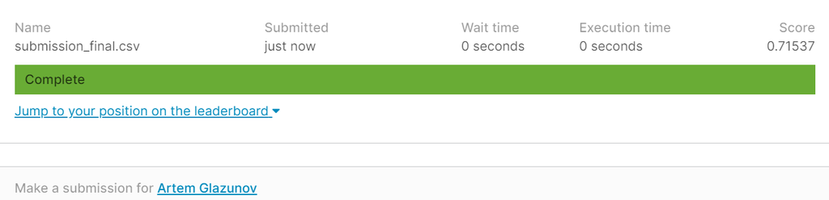

10. Подумайте, можно ли еще улучшить модель? Что для этого можно сделать?

**Данная модель - своего рода тоже бейзлайн. Многое можно еще попробовать, к примеру, другие способы отбора признаков с использование взаимной информации между признаком и откликом, другие методы обработки категориальных признаков (к примеру, SumEncoder,BackwardDifferenceEncoder), oversampling методами ближайших соседей, более тонкую и масштабную кросс-валидации. Также интерес представляет использование каскадов разных по математической структуре алгоритмов с последующим смешивание ответов. Все это трудно реализовать на моей машине, но вот, к примеру, Google Colab подходит идеально.**

**Но основной целью данной работы для меня было не получение наилучшей модели или победа в соревновании. Главное - это собрать наиболее интересные наработки по классификации, которые будут полезны мне и другим в дальнейшей практике.**